Matthew Afoakwah

# Video Game Sales Investment Study

Matthew Afoakwah, Nathan Cummings, Jaye Evans, Nikola Ignjatovic, Kevin Mainello, Chris Weiner

March 28th, 2023

## Abstract

This project is based on an Investors desire to invest in Video Games. Before the investor can invest, it is our job to investigate where the investor should best invest their money in a means that will ultimately benefit the investor. To accomplish this, we use a Video Game data set from 2010 to 2016. We will prepare the data set by exploring and cleaning the data set to create proper visualizations and models for the investor. At the end of this project, we will explain to the investor our findings based on our visualizations and models.

## 1. Scenario

Suppose there is an investor who wants to invest in a gaming platform. However, before the investor funds, they want to know which gaming platform between the years 2010 to 2016 has the best NA, EU, and Global sales. The investor also wants to know what video game category produces the most income between 2010 and 2016 for each video game platform so that they can better invest their money to better profit themselves. The investor also wants to see what game developers create more profitable games and the video game categories those developers mainly develop. The investor wants an in-depth analysis of video game platforms, categories, and developers before investing money.

## 2.Preparation

The data we are using was uploaded to Kaggle by SID_TWR. SID_TWR stated that this dataset was scraped from VGChartz and Metacritic.

2.1 Load Tidyverse package Before we work on our data, we first want to load it into R, but first, we must add two R packages into R before we attempt to work with data.

```r
# install.packages('Tidyverse')

                            library(tidyverse)  #Used to load tidyverse package in R.
```

[output not shown]

```r
library(readr)  #Used to load readr package in R to use to read CSV file.
```

2.2 Import dataset Now we want to import our dataset into R using the read_CSV function from our readr package.

```r
# Reads the CSV file from the file location using read_csv, and imports the
                            # file into R, named Video_Games_Sales.
                            Video_Games_Sales <- read_csv("data/Video_Games_Sales_as_at_22_Dec_2016.csv")
```

```
                            ## ── Column specification ────────────────────────────────────────────────────────
                            ## Delimiter: ","
                            ## chr (7): Name, Platform, Year_of_Release, Genre, Publisher, Developer, Rating
                            ## dbl (9): NA_Sales, EU_Sales, JP_Sales, Other_Sales, Global_Sales, Critic_Sco...
                            ##
                            ## ℹ Use `spec()` to retrieve the full column specification for this data.
                            ## ℹ Specify the column types or set `show_col_types = FALSE` to quiet this message.
```

2.3 Preview dataset Before we can work on our dataset, we must first see if the dataset is relevant to our task. To accomplish this, we must explore the dataset in R.

```r
# we use the head() function to get a preview of the dataset.
                            head(Video_Games_Sales)
```

```
## # A tibble: 6 × 16
                            ##   Name     Platf…¹ Year_…² Genre Publi…³ NA_Sa…⁴ EU_Sa…⁵ JP_Sa…⁶ Other…⁷ Globa…⁸
                            ##   <chr>    <chr>   <chr>   <chr> <chr>     <dbl>   <dbl>   <dbl>   <dbl>   <dbl>
                            ## 1 Wii Spo… Wii     2006    Spor… Ninten…    41.4   29.0     3.77    8.45    82.5
                            ## 2 Super M… NES     1985    Plat… Ninten…    29.1    3.58    6.81    0.77    40.2
                            ## 3 Mario K… Wii     2008    Raci… Ninten…    15.7   12.8     3.79    3.29    35.5
                            ## 4 Wii Spo… Wii     2009    Spor… Ninten…    15.6   10.9     3.28    2.95    32.8
                            ## 5 Pokemon… GB      1996    Role… Ninten…    11.3    8.89   10.2     1       31.4
                            ## 6 Tetris   GB      1989    Puzz… Ninten…    23.2    2.26    4.22    0.58    30.3
                            ## # … with 6 more variables: Critic_Score <dbl>, Critic_Count <dbl>,
                            ## #   User_Score <dbl>, User_Count <dbl>, Developer <chr>, Rating <chr>, and
                            ## #   abbreviated variable names ¹Platform, ²Year_of_Release, ³Publisher,
                            ## #   ⁴NA_Sales, ⁵EU_Sales, ⁶JP_Sales, ⁷Other_Sales, ⁸Global_Sales
```

We have now seen some of the data set, but before we can verify that the data set is relevant, we must explore the data set further. To accomplish this, we use the glimpse() function.

```r
# shows a glimpse of the data set along with the attributes.
                            glimpse(Video_Games_Sales)
```

```
## Rows: 16,719
                            ## Columns: 16
                            ## $ Name            <chr> "Wii Sports", "Super Mario Bros.", "Mario Kart Wii", "…
                            ## $ Platform        <chr> "Wii", "NES", "Wii", "Wii", "GB", "GB", "DS", "Wii", "…
                            ## $ Year_of_Release <chr> "2006", "1985", "2008", "2009", "1996", "1989", "2006"…
                            ## $ Genre           <chr> "Sports", "Platform", "Racing", "Sports", "Role-Playin…
                            ## $ Publisher       <chr> "Nintendo", "Nintendo", "Nintendo", "Nintendo", "Ninte…
                            ## $ NA_Sales        <dbl> 41.36, 29.08, 15.68, 15.61, 11.27, 23.20, 11.28, 13.96…
                            ## $ EU_Sales        <dbl> 28.96, 3.58, 12.76, 10.93, 8.89, 2.26, 9.14, 9.18, 6.9…
                            ## $ JP_Sales        <dbl> 3.77, 6.81, 3.79, 3.28, 10.22, 4.22, 6.50, 2.93, 4.70,…
                            ## $ Other_Sales     <dbl> 8.45, 0.77, 3.29, 2.95, 1.00, 0.58, 2.88, 2.84, 2.24, …
                            ## $ Global_Sales    <dbl> 82.53, 40.24, 35.52, 32.77, 31.37, 30.26, 29.80, 28.92…
                            ## $ Critic_Score    <dbl> 76, NA, 82, 80, NA, NA, 89, 58, 87, NA, NA, 91, NA, 80…
                            ## $ Critic_Count    <dbl> 51, NA, 73, 73, NA, NA, 65, 41, 80, NA, NA, 64, NA, 63…
                            ## $ User_Score      <dbl> 8.0, NA, 8.3, 8.0, NA, NA, 8.5, 6.6, 8.4, NA, NA, 8.6,…
                            ## $ User_Count      <dbl> 322, NA, 709, 192, NA, NA, 431, 129, 594, NA, NA, 464,…
                            ## $ Developer       <chr> "Nintendo", NA, "Nintendo", "Nintendo", NA, NA, "Ninte…
                            ## $ Rating          <chr> "E", NA, "E", "E", NA, NA, "E", "E", "E", NA, NA, "E",…
```

Now we want to look at all the columns within the data set. We accomplish this using the colnames() function.

```r
# Shows the name of the columns in the Video_Games_Sales data set.
                            colnames(Video_Games_Sales)
```

```
##  [1] "Name"            "Platform"        "Year_of_Release" "Genre"
                            ##  [5] "Publisher"       "NA_Sales"        "EU_Sales"        "JP_Sales"
                            ##  [9] "Other_Sales"     "Global_Sales"    "Critic_Score"    "Critic_Count"
                            ## [13] "User_Score"      "User_Count"      "Developer"       "Rating"
```

Now we want to determine the dataset size, so we use the dim() function to discover the dataset size.

```r
# After using the dim() function we see that the length of the dataset is 16
                            # and that there is 16719 rows.
                            dim(Video_Games_Sales)
```

```
## [1] 16719    16
```

To continue our exploration, we wish to see the data type of each column. To accomplish this, we use the class function.

```r
# We use the sapply() function to apply the class function on each attribute of
                            # our data set.
                            sapply(Video_Games_Sales, class)
```

```
##            Name        Platform Year_of_Release           Genre       Publisher
                            ##     "character"     "character"     "character"     "character"     "character"
                            ##        NA_Sales        EU_Sales        JP_Sales     Other_Sales    Global_Sales
                            ##       "numeric"       "numeric"       "numeric"       "numeric"       "numeric"
                            ##    Critic_Score    Critic_Count      User_Score      User_Count       Developer
                            ##       "numeric"       "numeric"       "numeric"       "numeric"     "character"
                            ##          Rating
                            ##     "character"
```

Viewing our dataset shows that our data set is relevant to our task and has given us insight into our dataset, allowing us to move on to the next step.

## 3. Data Cleaning

Though we can see that our dataset has information that we can use, we must clean the data set using transformations to focus on the information we need.

3.1 Since we focusing video game sales between 2010 and 2016, we will filter the dataset.

```r
# Use the filter() function to filter out all rows where the release year is
                            # not between 2010 and 2016. Then we store it in a new data set called
                            # gamesales2010_2016.
                            gamesales2010_2016 <- filter(Video_Games_Sales, Year_of_Release >= 2010)
                            gamesales2010_2016 <- filter(gamesales2010_2016, Year_of_Release <= 2016)
                            # We use the dim() function and see that the amount of rows in the data set.
                            dim(gamesales2010_2016)
```

```
## [1] 5277   16
```

3.2 We will now filter all rows where the Year_of_Release is unknown.

```r
# The filter() function removes all values that are 'N/A' in the
                            # Year_of_Release column
                            gamesales2010_2016 <- filter(gamesales2010_2016, Year_of_Release != "N/A")
                            # nrow() prints out the number of rows in gamesales2010_2016.
                            nrow(gamesales2010_2016)
```

```
## [1] 5277
```

We have decided to remove all rows where the Year_of_Release is “N/A” because there are not too many “N/A” value’s missing in the Year_of_Release column, which would significantly impact our data set; because of this, we can easily remove the “N/A” values from the data set without having to worry about our results being greatly influenced.

3.3 We want to find and remove duplicated files, so we use the duplicated() function.

```r
# We use the duplicated() to find all rows where they are repeated occurrences.
                            # Then we use the ! to filter them out from the graph.
                            gamesales2010_2016 <- gamesales2010_2016[!duplicated(gamesales2010_2016), ]
                            # We use #nrow() function to view the amount of rows left in the dataset.
                            nrow(gamesales2010_2016)
```

```
## [1] 5277
```

After checking/removing all duplicated files in the dataset, we view how many rows are in the data set. We noticed that the number of rows did not decrease, so there were no repeated values in the dataset.

3.4 We want to identify any outliers in our data set before continuing any further. To accomplish this, we want to use a boxplot graph to identify any outliers in the graph. Because the numeric columns we will focus on are Global and NA Sales, we will only look for outliers in these two columns.

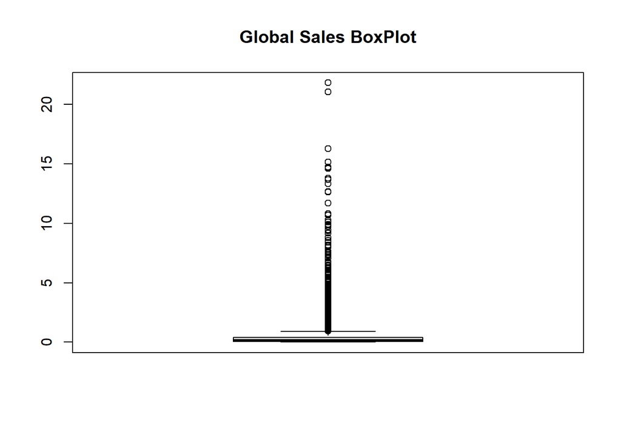

```r
# We create a boxplot for the Global Sales in gamesales_2010_2016 then set the
                            # title to 'Global Sales BoxPlot'.
                            boxplot(gamesales2010_2016$Global_Sales, main = "Global Sales BoxPlot")
```

```r
# We create a new variable outliers, then use boxplot.stats() to assign our
                            # outliers from Global sales to outliers.
                            outliers <- boxplot.stats(gamesales2010_2016$Global_Sales)$out
```

This boxplot visually represents the max, min, and median values in the Global sales of our dataset.

We can see some outliers in the Global Sales; this allows us to remove them from our dataset. However, we will not remove them as they will also not affect our progress. Now, we will check the outliers for the NA Sales.

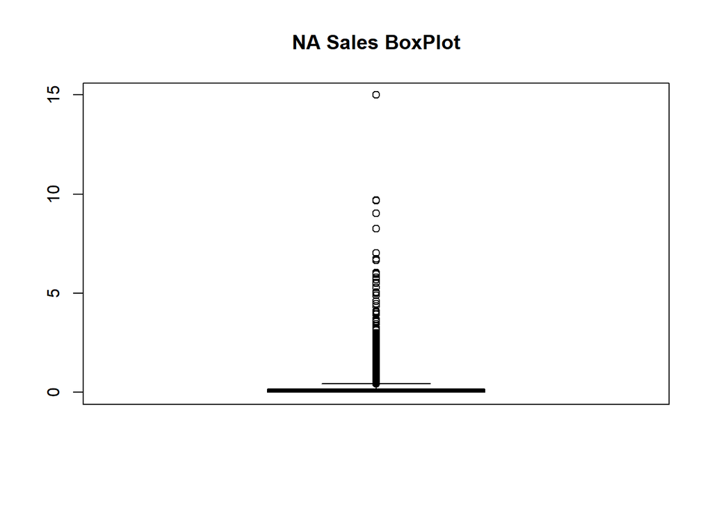

```r
# We create a boxplot for the NA Sales in gamesales_2010_2016 then set the
                            # title to 'NA Sales BoxPlot'.
                            boxplot(gamesales2010_2016$NA_Sales, main = "NA Sales BoxPlot")
```

```r
# We create a new variable outliersNA, then use boxplot.stats() to assign our
                            # outliers from NA sales to outliersNA.
                            outliersNA <- boxplot.stats(gamesales2010_2016$NA_Sales)$out
```

This boxplot visually represents the max, min, and median values in the NA sales of our data set.

In this dataset, outliers are usually the top-selling games or those that sell very little; this is why we did not remove any outliers, as it is valuable data and is relevant to what we will be searching for in the data set.

## 4. Data Exploration

We now develop questions to explore the data set even further.

1. Which video game platform made the most NA Sales from 2010 to 2016?
2. Which video game platform made the most Global Sales from 2010 to 2016?
3. Which video game category had the highest NA sales?
4. Which video game category made the highest Global sales?
5. Which top five video game developers have the highest Global sales?
6. Which video game genre is the top five developers most profitable in?

4.1 Before we can answer the questions, we first want to explore the unique attributes in the platform column to see if any discrepancies need to be fixed.

```r
# unique() function lists the unique characters in the platform column.
                            unique(gamesales2010_2016$Platform)
```

```
##  [1] "X360" "PS3"  "DS"   "PS4"  "3DS"  "Wii"  "XOne" "WiiU" "PC"   "PSP"
                            ## [11] "PSV"  "PS2"
```

From looking at the unique attributes in the platform column, we have irregularities, so we need to recode the names in Platform using the recode() function.

```r
# We use recode() to change the values of certain attributes to new attributes
                            # such as Nintendo, PlayStation, and Xbox.
                            gamesales2010_2016$Platform <- recode(gamesales2010_2016$Platform, X360 = "Xbox",
                                PS3 = "PlayStation", DS = "Nintendo", PS4 = "PlayStation", `3DS` = "Nintendo",
                                Wii = "Nintendo", XOne = "Xbox", WiiU = "Nintendo", PSP = "PlayStation", PSV = "PlayStation",
                                PS2 = "PlayStation")
                            # We use unique()to list the unique attributes in the platform column.
                            unique(gamesales2010_2016$Platform)
```

```
## [1] "Xbox"        "PlayStation" "Nintendo"    "PC"
```

We have finished changing the attributes in the Platform column and can now move on to our next task.

4.2 To answer the first question, we must calculate the NA revenue for each Platform.

```r
# We move the gamesales2010_2016 data into a new dataset.
                            platform_NA_Sales <- gamesales2010_2016 %>%
                                # We use the group_by() to group all the platforms in the platform_NA_Sales
                                # together.
                            group_by(Platform) %>%
                                # We use the summarize() to summarize the sum of NA_sales for each
                                # different platform.
                            summarize(NA_total = sum(NA_Sales)) %>%
                                # We arrange the data set by decreasing order according to the NA_total.
                            arrange(desc(NA_total))
                            # We use the head() function to preview the new data set.
                            head(platform_NA_Sales)
```

```
## # A tibble: 4 × 2
                            ##   Platform    NA_total
                            ##   <chr>          <dbl>
                            ## 1 Xbox           427.
                            ## 2 PlayStation    362.
                            ## 3 Nintendo       302.
                            ## 4 PC              39.1
```

What this code does is that it sums up the total NA sales made between 2010 to 2016 for each video game platform. We create another table that calculates the NA and Global sales for each Platform for every year.

```r
# We move the gamesales2010_2016 data into a new data set.
                            platform_SalesbyYear <- gamesales2010_2016 %>%
                                # We use the group_by() to group all the Platform and Year_of_Release
                                # together.
                            group_by(Platform, Year_of_Release) %>%
                                # We use the summarize() to summarize the sum of NA_sales for each
                                # different platform, and year.
                            summarize(NA_total = sum(NA_Sales), glbl_total = sum(Global_Sales)) %>%
                                # We arrange the data set by decreasing order according to the glbl_total.
                            arrange(desc(glbl_total))
```

[output not shown]

```r
# We use the head() function to preview the new data set.
                            head(platform_SalesbyYear)
```

```
## # A tibble: 6 × 4
                            ## # Groups:   Platform [3]
                            ##   Platform    Year_of_Release NA_total glbl_total
                            ##   <chr>       <chr>              <dbl>      <dbl>
                            ## 1 Nintendo    2010               113.        213.
                            ## 2 PlayStation 2010                70.6       183.
                            ## 3 PlayStation 2011                68.6       180.
                            ## 4 Xbox        2010               107.        170.
                            ## 5 PlayStation 2014                53.1       160.
                            ## 6 PlayStation 2013                54.1       153.
```

What this code does is that it calculates the total NA and Global sales of each Platform based on the year. This will allow us to find a trend in the profit of each Platform.

4.3 Secondly, we calculate the global revenue for each Platform.

```r
# We move the gamesales2010_2016 data into a new dataset then pipe the command.
                            platform_glbl_sales <- gamesales2010_2016 %>%
                                # We use the group_by() to group all the platforms together.
                            group_by(Platform) %>%
                                # We use the summarize function to summarize the sum of Global_sales for
                                # each different platform.
                            summarize(glbl_total = sum(Global_Sales)) %>%
                                # We arrange the data set by decreasing order according to the glbl_total.
                            arrange(desc(glbl_total))
                            # We use the head() function to preview the table.
                            head(platform_glbl_sales)
```

```
## # A tibble: 4 × 2
                            ##   Platform    glbl_total
                            ##   <chr>            <dbl>
                            ## 1 PlayStation      1026.
                            ## 2 Xbox              710.
                            ## 3 Nintendo          687.
                            ## 4 PC                122.
```

4.4 Now, we want to calculate the NA revenue based on genre. But before we can do that, we must see if there are any dependencies with the character values in the genre.

```r
# We use the unique to search for any irregular values in the categories
                            # column.
                            unique(gamesales2010_2016$Genre)
```

```
##  [1] "Misc"         "Action"       "Role-Playing" "Shooter"      "Racing"
                            ##  [6] "Platform"     "Simulation"   "Sports"       "Fighting"     "Strategy"
                            ## [11] "Adventure"    "Puzzle"
```

After using the unique() function, we see that there are not any irregularities which allow us to continue to calculate the NA revenue based on genre.

```r
# We move the gamesales2010_2016 data into a new dataset.
                            genre_na_sales <- gamesales2010_2016 %>%
                                # We use the group_by() to group all the Genres together.
                            group_by(Genre) %>%
                                # We use summarize() to summarize the sum of na_sales for each different
                                # genre.
                            summarise(genre_na_total = sum(NA_Sales)) %>%
                                # We arrange the dataset by decreasing order according to the
                                # genre_na_total.
                            arrange(desc(genre_na_total))
                            # We use the head() function to preview the table.
                            head(genre_na_sales)
```

```
## # A tibble: 6 × 2
                            ##   Genre        genre_na_total
                            ##   <chr>                 <dbl>
                            ## 1 Action                291.
                            ## 2 Shooter               237.
                            ## 3 Sports                157.
                            ## 4 Misc                  124.
                            ## 5 Role-Playing          112.
                            ## 6 Platform               54.9
```

We now create another table that separates the NA sales by genre for each year.

```r
# We move the gamesales2010_2016 data into a new dataset.
                            genre_SalesbyYear <- gamesales2010_2016 %>%
                                # We use the group_by() to group all the Genre and Year_of_Release
                                # together.
                            group_by(Genre, Year_of_Release) %>%
                                # We use the summarize() to summarize the sum of NA_sales for each
                                # different Genre, and year.
                            summarize(NA_total = sum(NA_Sales), glbl_total = sum(Global_Sales)) %>%
                                # We arrange the dataset by decreasing order according to the glbl_total.
                            arrange(desc(glbl_total))
```

[output not shown]

```r
# We use the head() function to preview the new dataset.
                            head(genre_SalesbyYear)
```

```
## # A tibble: 6 × 4
                            ## # Groups:   Genre [2]
                            ##   Genre   Year_of_Release NA_total glbl_total
                            ##   <chr>   <chr>              <dbl>      <dbl>
                            ## 1 Action  2013                53.5      123.
                            ## 2 Action  2012                51.8      119.
                            ## 3 Action  2011                53.1      117.
                            ## 4 Action  2010                59.7      115.
                            ## 5 Shooter 2011                49.7       98.2
                            ## 6 Action  2014                38.8       97.3
```

4.5 We now want to calculate the Global revenue based on genre.

```r
# We move the gamesales2010_2016 data into a new dataset then pipe the command.
                            genre_glbl_sales <- gamesales2010_2016 %>%
                                # We use group_by() to group all the Genres in the genre_glbl_sales
                                # together.
                            group_by(Genre) %>%
                                # We use summarize() to summarize the sum of Global_sales for each
                                # different genre.
                            summarise(genre_glbl_total = sum(Global_Sales)) %>%
                                # We arrange the dataset by decreasing order according to the
                                # genre_na_total.
                            arrange(desc(genre_glbl_total))
                            # We use the head() function to preview the table.
                            head(genre_glbl_sales)
```

```
## # A tibble: 6 × 2
                            ##   Genre        genre_glbl_total
                            ##   <chr>                   <dbl>
                            ## 1 Action                   673.
                            ## 2 Shooter                  480.
                            ## 3 Sports                   329.
                            ## 4 Role-Playing             315.
                            ## 5 Misc                     235.
                            ## 6 Racing                   123.
```

4.6 Before we can attempt to calculate NA and Global sales based on the Developer, we must first determine whether there are any irregularities in the Developer column.

```r
# We use unique() to take all unique values in the developer column then sort
                            # them.
                            unique_dev <- sort(unique(gamesales2010_2016$Developer))
```

After placing all the unique values from the Developer column of the dataset gamesales2010_2016 in a new set, we see that there are over 800 different values, and there are bound to be some missed spelled values, so we review all the unique values and change their names to match what we want it to be. Some values may have been in a different region but are part of a company. Still, because we want the overall company, we also change the different region companies to match its parent company.

```r
# We use the recode() function from the dplyr package from our tidyverse
                            # package in order change our variables.
                            gamesales2010_2016$Developer <- recode(gamesales2010_2016$Developer, `1C: Maddox Games` = "1C Company",
                                `1C:Ino-Co` = "1C Company", `2K Australia` = "2K Games", `2K Czech` = "2K Games",
                                `2K Sports` = "2K Games", `2K Marin` = "2K Games", `2K Play` = "2K Games", `505 Games, Sarbakan Inc.` = "505 Games",
                                `Activision, Behaviour Interactive` = "Activision", `Activision, FreeStyleGames` = "Activision",
                                `Ambrella, The Pokemon Company` = "Ambrella", `Armature Studio, comcept` = "Armature Studio",
                                `Artificial Mind and Movement, EA Redwood Shores` = "Artificial Mind and Movement",
                                `Atari, Atari SA` = "Atari", `Atari, Slightly Mad Studios, Atari SA` = "Atari",
                                `Atlus, Dingo Inc.` = "Atlus", `Atomic Planet Entertainment` = "Atomic Games",
                                `Avalanche Software` = "Avalanche Studios", `Bandai Namco Games, Artdink` = "Bandai Namco Games",
                                `Beenox, Other Ocean Interactive` = "Beenox", `Big Blue Bubble Inc., Scholastic, Inc.` = "Big Blue Bubble Inc.",
                                `Big Blue Bubble Inc., Scholastic, Inc.` = "Big Blue Bubble Inc.", `Blitz Games Studios` = "Blitz Games",
                                `Blue Byte, Related Designs` = "Blue Byte", `Bungie Software, Bungie` = "Bungie",
                                `Capcom Vancouver` = "Capcom", `Capcom, Pipeworks Software, Inc.` = "Capcom")

                            gamesales2010_2016$Developer <- recode(gamesales2010_2016$Developer, `Capcom, QLOC` = "Capcom",
                                `Climax Entertainment` = "Climax Studios", `Climax Group` = "Climax Studios",
                                `Climax Group, Climax Studios` = "Climax Studios", `Codemasters Birmingham` = "Codemasters",
                                `Compile Heart, GCREST` = "Compile Heart", `Crave, DTP Entertainment` = "Crave",
                                `Crystal Dynamics, Nixxes Software` = "Crystal Dynamics", `Cyanide, Cyanide Studios` = "Cyanide",
                                `CyberConnect2, Racjin` = "CyberConnect2", `CyberPlanet Interactive Public Co., Ltd., Maximum Family Games` = "CyberPlanet Interactive Public Co., Ltd.",
                                `Deep Silver Dambuster Studios` = "Deep Silver", `Deep Silver, Keen Games` = "Deep Silver",
                                `Dimps Corporation, Dream Execution` = "Dimps Corporation", `Dimps Corporation, SCE Japan Studio` = "Dimps Corporation",
                                `Disney Interactive Studios, Land Ho!` = "Disney Interactive Studios", `EA Black Box` = "EA Games",
                                `EA Bright Light` = "EA Games", `EA Canada` = "EA Games", `EA Canada, EA Vancouver` = "EA Games",
                                `EA DICE` = "EA Games", `EA DICE, Danger Close` = "EA Games")
                            #'EA Sports' = 'EA Games'

                            gamesales2010_2016$Developer <- recode(gamesales2010_2016$Developer, `EA Sports` = "EA Games",
                                `EA Montreal` = "EA Games", `EA Redwood Shores` = "EA Games", `EA Sports, EA Canada` = "EA Games",
                                `EA Sports, EA Vancouver` = "EA Games", `EA Tiburon` = "EA Games", `Eidos Montreal, Nixxes Software` = "Eidos Montreal",
                                `Engine Software, Re-Logic` = "Engine Software", `Epic Games, People Can Fly` = "Epic Games",
                                `Farsight Studios, Crave` = "Farsight Studios", `Gaijin Entertainment` = "Gaijin Games",
                                `Gearbox Software, 3D Realms` = "Gearbox Software", `Gearbox Software, WayForward` = "Gearbox Software",
                                `Guerilla Cambridge` = "Guerrilla Cambridge", Guerilla = "Guerilla Cambridge")


                            gamesales2010_2016$Developer <- recode(gamesales2010_2016$Developer, `Harmonix Music Systems, Demiurge` = "Harmonix Music Systems",
                                `Headup Games, Crenetic Studios` = "Headup Games", `Konami Computer Entertainment Hawaii` = "Konami",
                                `Marvelous AQL` = "Marvelous Inc.", `Marvelous Entertainment` = "Marvelous Inc.",
                                `Midway Studios - Austin` = "Midway", `Monolith Soft` = "Monolith Productions",
                                `Monolith Soft, Banpresto` = "Monolith Productions")

                            gamesales2010_2016$Developer <- recode(gamesales2010_2016$Developer, `Namco Bandai Games America, Namco Bandai Games` = "Namco Bandai Games",
                                `Namco Bandai Games, Bandai Namco Games` = "Namco Bandai Games", `Namco Bandai Games, Cellius` = "Namco Bandai Games",
                                `Namco Bandai Games, Monkey Bar Games` = "Namco Bandai Games", `NATSUME ATARI Inc.` = "Natsume",
                                `Nintendo EAD Tokyo` = "Nintendo", `Nintendo, Camelot Software Planning` = "Nintendo",
                                `Nintendo, Headstrong Games` = "Nintendo", `Nintendo, Intelligent Systems` = "Nintendo",
                                `Nintendo, Nd Cube` = "Nintendo", `Nintendo, Nintendo Software Technology` = "Nintendo",
                                `Nintendo, Spike Chunsoft` = "Nintendo", `Paradox Development Studio` = "Paradox Interactive")


                            gamesales2010_2016$Developer <- recode(gamesales2010_2016$Developer, `PLAYGROUND, Playground Games` = "Playground Games",
                                `Retro Studios, Entertainment Analysis & Development Division` = "Retro Studios",
                                `Rockstar Leeds` = "Rockstar Studios", `Rockstar North` = "Rockstar Studios",
                                `Rockstar San Diego` = "Rockstar Studios", `Sanzaru Games, Sanzaru Games, Inc.` = "Sanzaru Games",
                                `SCE Japan Studio, comcept` = "SCE Studio", `SCE Santa Monica` = "SCE Studio",
                                `SCE Studio Cambridge` = "SCE Studio", `SCE Japan Studio` = "SCE Studio", `SCEA San Diego Studios` = "SCEA",
                                `SCEA, Zindagi Games` = "SCEA", `SCEE London Studio` = "SCEE")

                            gamesales2010_2016$Developer <- recode(gamesales2010_2016$Developer, `Sega Studios San Francisco` = "Sega",
                                `Sega Toys` = "Sega", `Sega, Dimps Corporation` = "Sega", `Sega, French-Bread` = "Sega",
                                `Sega, Sonic Team` = "Sega", Snapdragon = "Snap Dragon Games", `Sonic Team` = "Sega",
                                `Sony Bend` = "Sony Interactive Entertainment", `Sony Online Entertainment` = "Sony Interactive Entertainment",
                                `Spike Chunsoft` = "Spike", `Spike Chunsoft Co. Ltd., Spike Chunsoft` = "Spike",
                                Tecmo = "Tecmo Koei Games", `Tecmo Koei Canada` = "Tecmo Koei Games", `THQ Australia` = "THQ",
                                `THQ Digital Studio Phoenix` = "THQ", `Ubisoft Casablanca` = "Ubisoft", `Ubisoft Milan` = "Ubisoft",
                                `Ubisoft Montpellier` = "Ubisoft", `Ubisoft Montreal` = "Ubisoft", `Ubisoft Osaka` = "Ubisoft",
                                `Ubisoft Paris` = "Ubisoft", `Ubisoft Paris, Ubisoft Montpellier` = "Ubisoft",
                                `Ubisoft Quebec` = "Ubisoft", `Ubisoft Reflections` = "Ubisoft", `Ubisoft Reflections, Ivory Tower` = "Ubisoft",
                                `Ubisoft Romania` = "Ubisoft", `Ubisoft Sofia` = "Ubisoft", `Ubisoft Toronto` = "Ubisoft",
                                `Ubisoft Vancouver` = "Ubisoft", `Ubisoft, FunHouse` = "Ubisoft", `Ubisoft, Ludia Inc.` = "Ubisoft",
                                `Ubisoft, Ubisoft Montreal` = "Ubisoft")
```

Because of the many values in the Developer column, many values needed to be changed in the dataset.

4.7 Since we have recoded the values in the Developers column, we can now calculate the global revenue based on the Developer.

```r
dev_global <- gamesales2010_2016 %>%
                                # We want to filter out any unknown Developers as there are so few NA
                                # developers that will affect our variables.
                            filter(Developer != "N/A") %>%
                                # We will then group the columns according to the value in the developer
                                # columns.
                            group_by(Developer) %>%
                                # We sum up the total global sales and NA sales of each developers games
                                # earned.
                            summarise(global_total = sum(Global_Sales)) %>%
                                # We then arrange each row in descending order based on the global_total.
                            arrange(desc(global_total)) %>%
                                # We use the slice_head() function to take ONLY the top five most
                                # profitable developers.
                            slice_head(n = 5)
                            # We preview the dataset.
                            head(dev_global)
```

```
## # A tibble: 5 × 2
                            ##   Developer        global_total
                            ##   <chr>                   <dbl>
                            ## 1 EA Games                209.
                            ## 2 Ubisoft                 183.
                            ## 3 Nintendo                 95.0
                            ## 4 Rockstar Studios         75.7
                            ## 5 Treyarch                 58.4
```

```r
# We create a table which shows video games where the developers are the top
                            # five developers.
                            developer_genre_sale <- gamesales2010_2016 %>%
                                filter(Developer %in% c("EA Games", "Ubisoft", "Nintendo", "Rockstar Studios",
                                    "Treyarch"))
                            # We use this to preview the data set.
                            head(developer_genre_sale)
```

```
## # A tibble: 6 × 16
                            ##   Name     Platf…¹ Year_…² Genre Publi…³ NA_Sa…⁴ EU_Sa…⁵ JP_Sa…⁶ Other…⁷ Globa…⁸
                            ##   <chr>    <chr>   <chr>   <chr> <chr>     <dbl>   <dbl>   <dbl>   <dbl>   <dbl>
                            ## 1 Grand T… PlaySt… 2013    Acti… Take-T…    7.02    9.09    0.98    3.96    21.0
                            ## 2 Grand T… Xbox    2013    Acti… Take-T…    9.66    5.14    0.06    1.41    16.3
                            ## 3 Call of… Xbox    2010    Shoo… Activi…    9.7     3.68    0.11    1.13    14.6
                            ## 4 Call of… PlaySt… 2012    Shoo… Activi…    4.99    5.73    0.65    2.42    13.8
                            ## 5 Call of… Xbox    2012    Shoo… Activi…    8.25    4.24    0.07    1.12    13.7
                            ## 6 Call of… PlaySt… 2010    Shoo… Activi…    5.99    4.37    0.48    1.79    12.6
                            ## # … with 6 more variables: Critic_Score <dbl>, Critic_Count <dbl>,
                            ## #   User_Score <dbl>, User_Count <dbl>, Developer <chr>, Rating <chr>, and
                            ## #   abbreviated variable names ¹Platform, ²Year_of_Release, ³Publisher,
                            ## #   ⁴NA_Sales, ⁵EU_Sales, ⁶JP_Sales, ⁷Other_Sales, ⁸Global_Sales
```

Now that we have isolated the video games developed by the top five Developers, we can group all the data by genre and Developer and calculate the global sale and NA sales based on the genre. But first, we must confirm the number of N/A values in our Genre column to see if those N/A’s will affect our results.

```r
# We use is.na() to determine if any values in Genre is N/A. Then use sum() to
                            # count the exact number of N/A values.
                            sum(is.na(developer_genre_sale$Genre))
```

```
## [1] 0
```

Fortunately, there are no N/A variables in the Genre column, so we can continue manipulating the dataset.

```r
# We store the developer_genre_sale data into df.
                            df <- developer_genre_sale %>%
                                # We then group by Developer and Genre.
                            group_by(Developer, Genre) %>%
                                # We summarise the NA and Global total for each category based on
                                # developer.
                            summarise(developer_glbl_total = sum(Global_Sales), developer_NA_total = sum(NA_Sales)) %>%
                                # We arrange the order in alphabetical order using the Developer column.
                            arrange(Developer)
```

[output not shown]

```r
# We preview the dataset.
                            head(df)
```

```
## # A tibble: 6 × 4
                            ## # Groups:   Developer [1]
                            ##   Developer Genre     developer_glbl_total developer_NA_total
                            ##   <chr>     <chr>                    <dbl>              <dbl>
                            ## 1 EA Games  Action                    5.3                3.55
                            ## 2 EA Games  Adventure                 0.32               0.17
                            ## 3 EA Games  Fighting                  2.61               1.24
                            ## 4 EA Games  Platform                  0.57               0.21
                            ## 5 EA Games  Racing                    1.56               0.62
                            ## 6 EA Games  Shooter                  49.7               23.1
```

## 5. Analyzing

Now that we have cleaned the data set and explored the dataset, we can now analyze the data set using visualization. In this section, we will use multiple different graphs to help identify and analyze our data to help the client understand where they would receive the most profit.

5.1 To answer our first question, we must determine the most profitable Platform and the rate of change between sales of each Platform from 2010 to 2016.

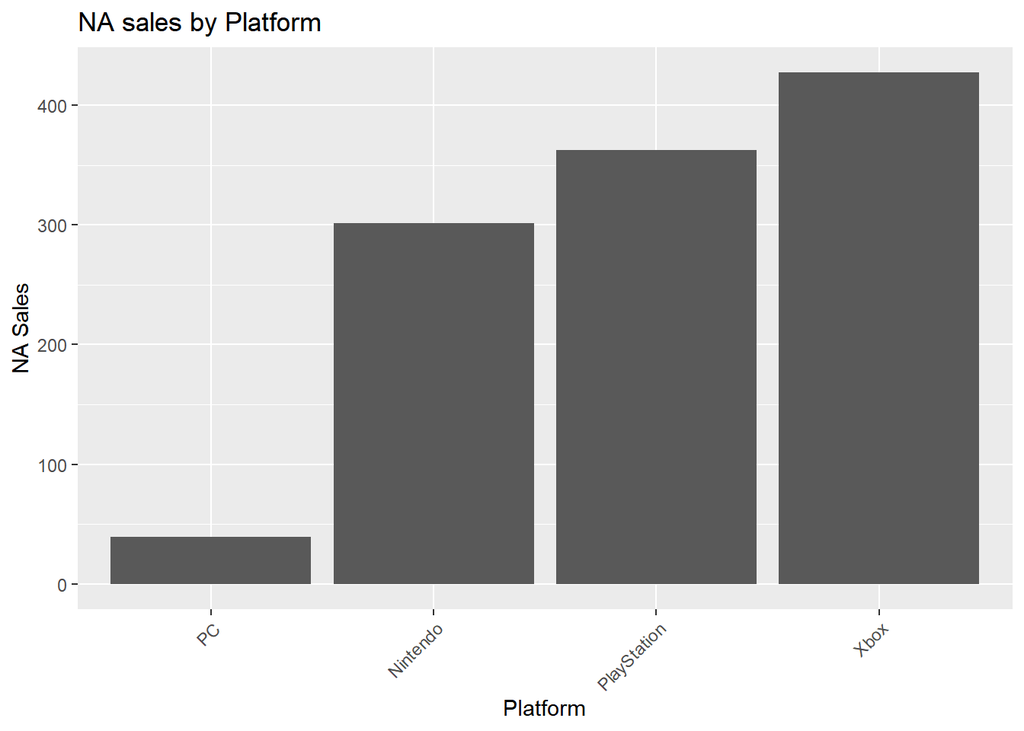

```r
# We use the ggplot2 package to create our graph, the aes() function is used to
                            # set the aesthetics of the plot.  We set our x value to Platform and our Y
                            # value to NA_total.  We use the reorder() function to reorder the graph from
                            # smallest to greatest.
                            ggplot(data = platform_NA_Sales, aes(x = reorder(Platform, NA_total), y = NA_total)) +
                                geom_bar(stat = "identity") + labs(title = "NA sales by Platform", x = "Platform",
                                y = "NA Sales") + theme(axis.text.x = element_text(angle = 45, hjust = 1))
```

```r
# labs() is used to changes the labels in various parts of the chart. Both the
                            # X and Y axis changing their names, as well as the title. theme() helps change
                            # non-data elements of a chart. In this case adding a change to Platform’s axis
                            # by utilizing element_text() to change the look of texts, adding an angle and
                            # using hjust to control horizontal justification)
```

This code produces the above graph in which it displays the sum of all Platforms in the 2010 to 2016 range.

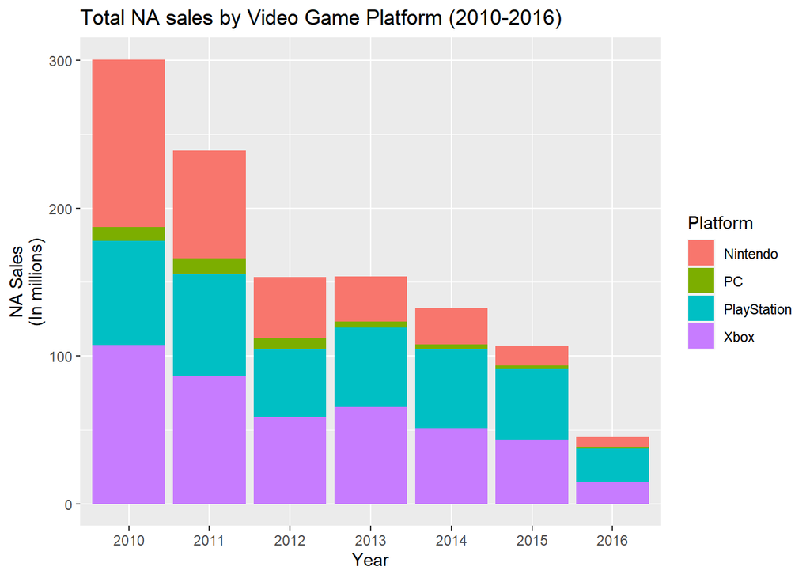

```r
# We use the ggplot2 package to create our graph, the aes() function is used to
                            # set the aesthetics of the plot. we set our x value to Year_of_Release, our Y
                            # value to NA_total, and fill based on platform.
                            ggplot(platform_SalesbyYear, aes(x = Year_of_Release, y = NA_total, fill = Platform)) +
                                geom_bar(stat = "identity") + labs(title = "Total NA sales by Video Game Platform (2010-2016)",
                                x = "Year", y = "NA Sales\n(In millions)")
```

```r
# labs() is used to changes the labels in various parts of the chart. Both the
                            # X and Y axis changing their names, as well as the title.
```

This code creates a bar graph that breaks up the total amount of NA sales for each Platform’s different years.

Analysis: Overall, these graphs show that Xbox is the most profitable Platform. However, compared to 2010, when it was at its highest, we can see that the sales for Xbox have been steadily declining same goes for the other platforms as well. But, compared to other platforms, PC has had the most negligible sales, and seen that by 2016 PlayStation had the highest sales.

5.2 To determine the most profitable Platform globally, we must first analyze the total sales made between 2010 and 2016 and the rate of change between these platforms.

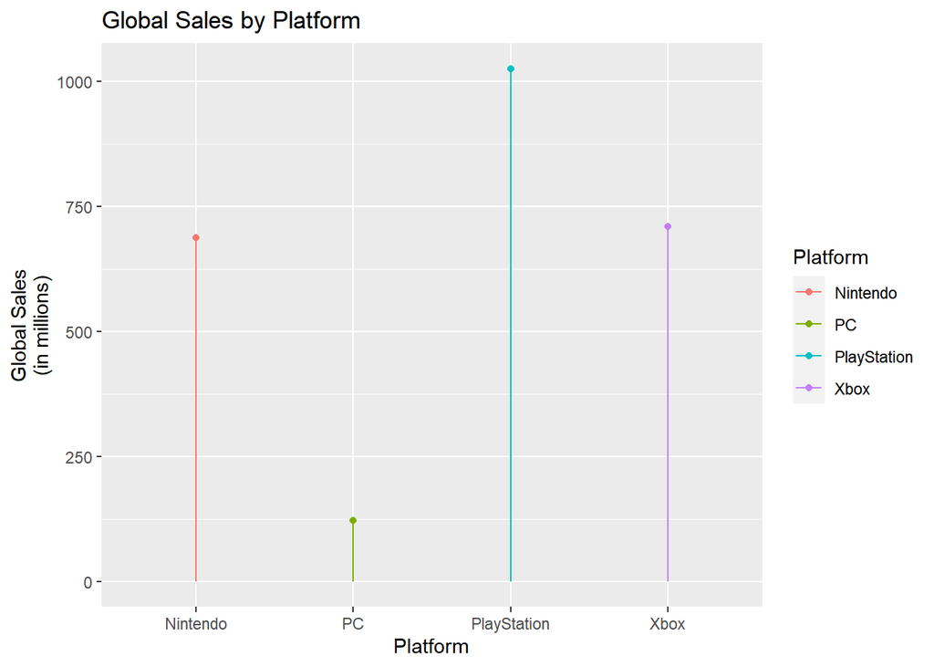

```r
# We use the ggplot2 package to create our graph, the aes() function is used to
                            # set the aesthetics of the plot. we set our x value to Platform, and our y
                            # value to glbl_total.
                            ggplot(platform_glbl_sales, aes(x = Platform, y = glbl_total, color = Platform)) +
                                geom_point(stat = "identity") + geom_segment(aes(x = Platform, xend = Platform,
                                y = 0, yend = glbl_total)) + labs(title = "Global Sales by Platform", x = "Platform",
                                y = "Global Sales\n(in millions)")
```

```r
# geom_point() sets a point at the value of each platforms global sales.
                            # geom_segment() creates lines at our platforms and reaches its total amount.
                            # We use labs() to rename the x and y axis as well as our title.
```

This code generates a lollipop graph in which it displays the total global sales of each platform in 2010 to 2016.

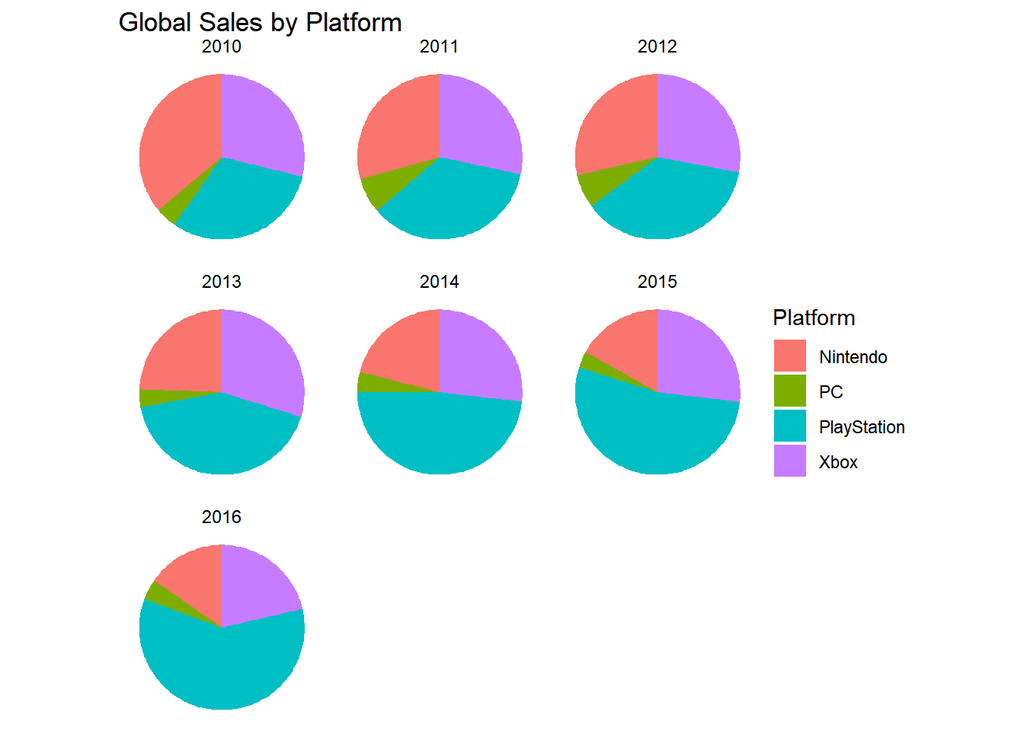

```r
ggplot(data = platform_SalesbyYear, aes(x = 0, y = glbl_total, fill = Platform)) +
                                geom_col(position = "fill") + facet_wrap(~Year_of_Release) + coord_polar(theta = "y") +
                                theme_void() + labs(title = "Global Sales by Platform")
```

This code generates pie charts which shows the difference in sales between each platform from 2010 to 2016.

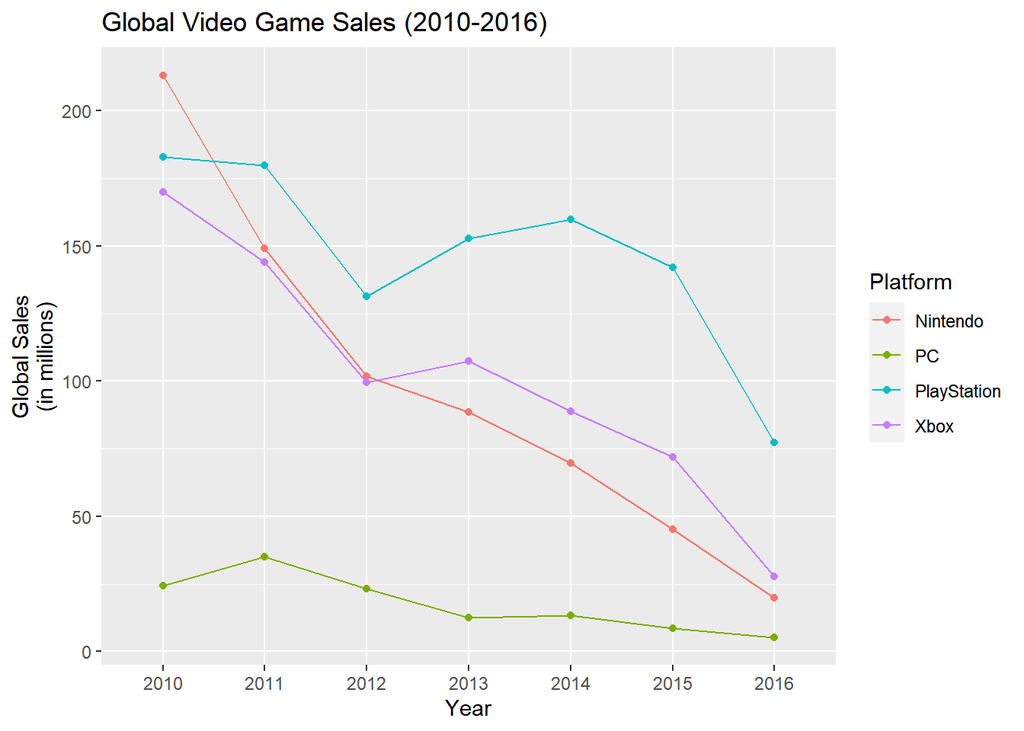

```r
# ggplot() is used to create the graph, and set the aesthetics of the graph.
                            # geom_point() is used to create a scatter plot of each platforms sales from
                            # 2010 to 2016.
                            ggplot(data = platform_SalesbyYear, aes(x = Year_of_Release, y = glbl_total, color = Platform)) +
                                geom_point() + geom_line(aes(group = Platform)) + labs(title = "Global Video Game Sales (2010-2016)",
                                x = "Year", y = "Global Sales\n(in millions)")
```

```r
# Geom_line is used to create a line graph and we set the aesthetic of the
                            # graph to group by Platform. labs() is used to change the names of our x and y
                            # axis as well as the title.
```

This code generates a line graph that shows the rate of increase/decrease of each Platform from 2010 to 2016.

5.3 We want to create visualizations for our third question to better understand the NA sales for each genre from 2010 to 2016.

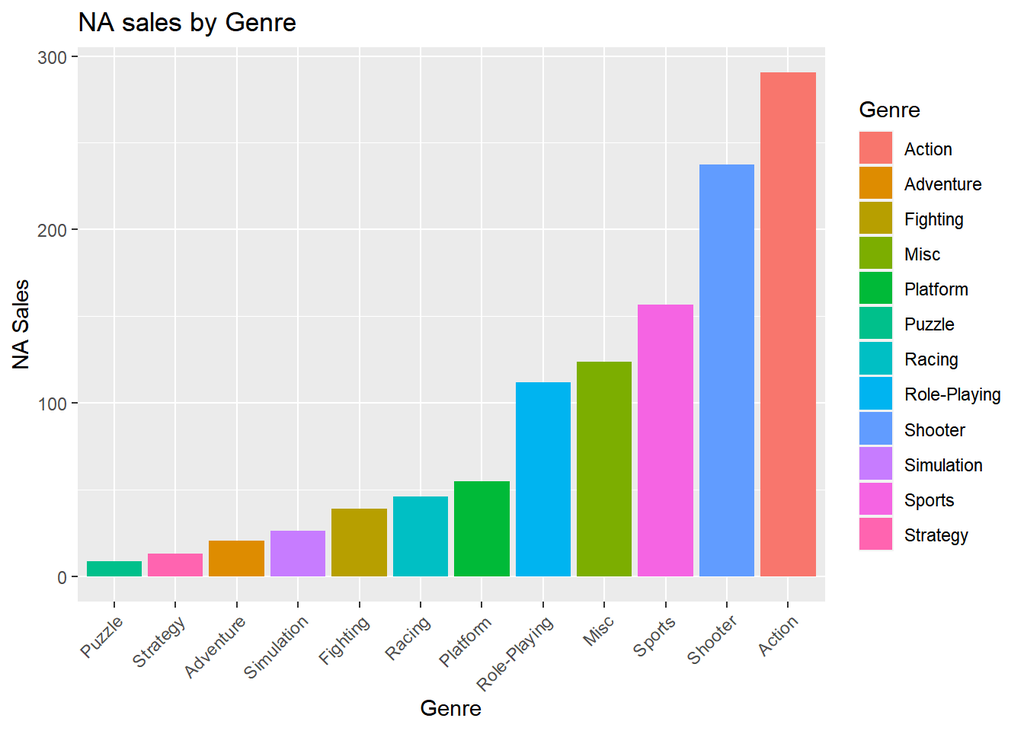

```r
# We use the ggplot2 package to create a Bar graph that easily represents the
                            # highest selling video game Genre for North American sales. We use the aes()
                            # function to label the axis’, as well as using fill for discernment between
                            # Genres, we use the reorder() function to arrange the attributes from least to
                            # greatest. geom_bar(stat=”identity”) makes a bar chart and makes the height
                            # proportional to the number of cases in each group. Stat identity displays the
                            # sum of values in the Sales(NA) column, grouped by Genre.
                            ggplot(data = genre_na_sales, aes(x = reorder(Genre, genre_na_total), y = genre_na_total,
                                fill = Genre)) + geom_bar(stat = "identity") + labs(title = "NA sales by Genre",
                                x = "Genre", y = "NA Sales") + theme(axis.text.x = element_text(angle = 45, hjust = 1))
```

```r
# labs() is used to changes the labels in various parts of the chart. Both the
                            # X and Y axis changing their names, as well as the title. theme() helps change
                            # non-data elements of a chart. In this case adding a change to Genre’s axis by
                            # utilizing element_text() to change the look of texts, adding an angle and
                            # using hjust to control horizontal justification)
```

This code creates a bar graph that displays the overall sum of sales of each genre between 2010 to 2016.

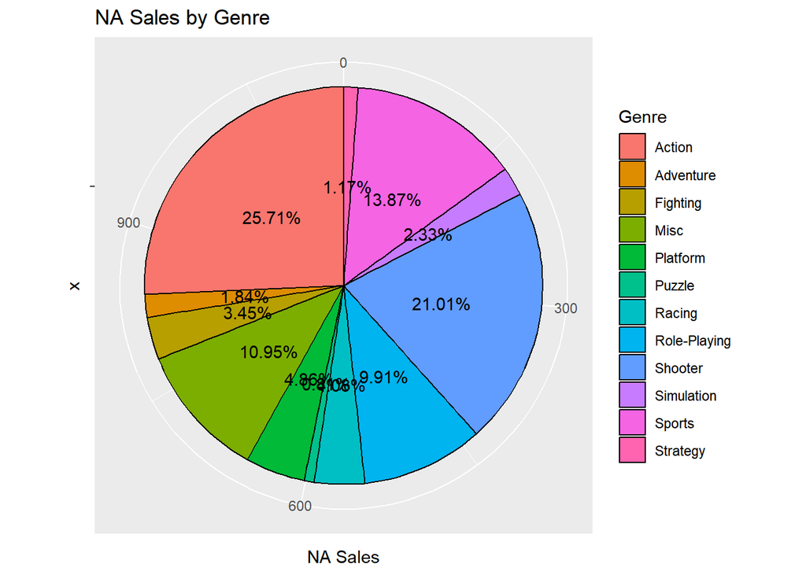

```r
# We convert our numeric values in genre_na_sales into a percentage of the
                            # entire sum and store it into pie_labels.
                            pie_labels <- paste0(round(100 * genre_na_sales$genre_na_total/sum(genre_na_sales$genre_na_total),
                                2), "%")
                            # We use ggplot() to create the graph, the aes() function set’s the aesthetic.
                            # Used nothing for X, but for Y we used NA Sales so that it would fill
                            # proportionately.We use the reorder() function to reorder the different
                            # Genre's from least to greatest. We then filled it by Genre using a rainbow
                            # palette. the geom_col() function is used to create black lines in between our
                            # “Slices”.
                            ggplot(genre_na_sales, aes(x = "", y = genre_na_total, fill = Genre)) + geom_col(color = "black") +
                                geom_text(aes(label = pie_labels), position = position_stack(vjust = 0.5)) +
                                coord_polar(theta = "y") + labs(y = "NA Sales", title = "NA Sales by Genre")
```

```r
# geom_text is used along with aes() embedded to set labels to pie labels and
                            # position them accordingly. coord_polar is used because a pie chart is
                            # actually just a stacked bar chart in polar coordinates. Then, we use the labs
                            # function to change the name of the y axis and title on the graph.
```

This code creates a pie graph, then displays the difference in NA sales each genre made out of 100% of the total sales made between 2010 to 2016

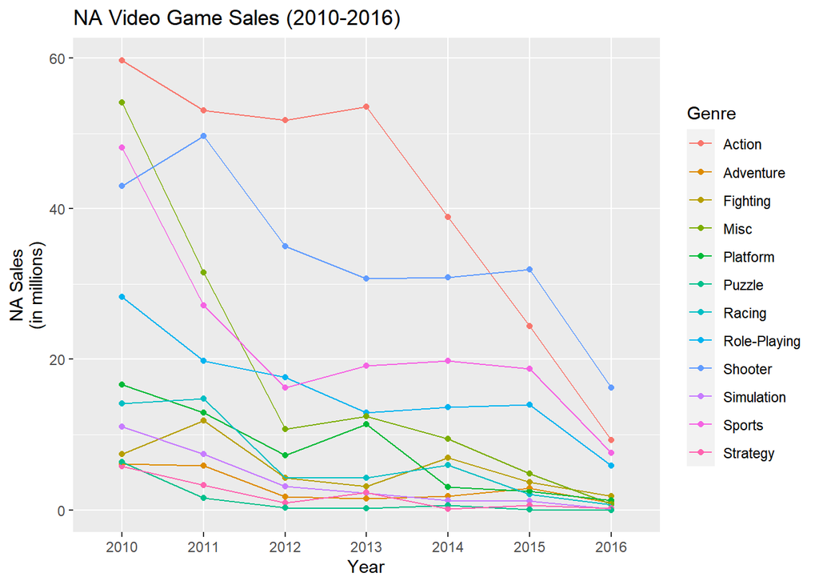

```r
# ggplot() is used to create the graph, and set the aesthetics of the graph.
                            # geom_point() is used to create a scatter plot of each platforms sales from
                            # 2010 to 2016.
                            ggplot(data = genre_SalesbyYear, aes(x = Year_of_Release, y = NA_total, color = Genre)) +
                                geom_point() + geom_line(aes(group = Genre)) + labs(title = "NA Video Game Sales (2010-2016)",
                                x = "Year", y = "NA Sales\n(in millions)")
```

```r
# Geom_line is used to create a line graph and we set the aesthetic of the
                            # graph to group by Genre. labs() is used to change the names of our x and y
                            # axis as well as the title.
```

This code creates a line graph that displays the change in NA sales based on each Genre over the past six years.

Analysis: Overall, we assume that Action is the most profitable video game genre compared to the other games. However, the sales of Action have dramatically decreased since 2013. While Shooter games have also decreased, it was the most profitable Genre 2016.

5.4 We now see the total global revenue based on Genre to get a visual for which Genre was more profitable throughout 2010-2016.

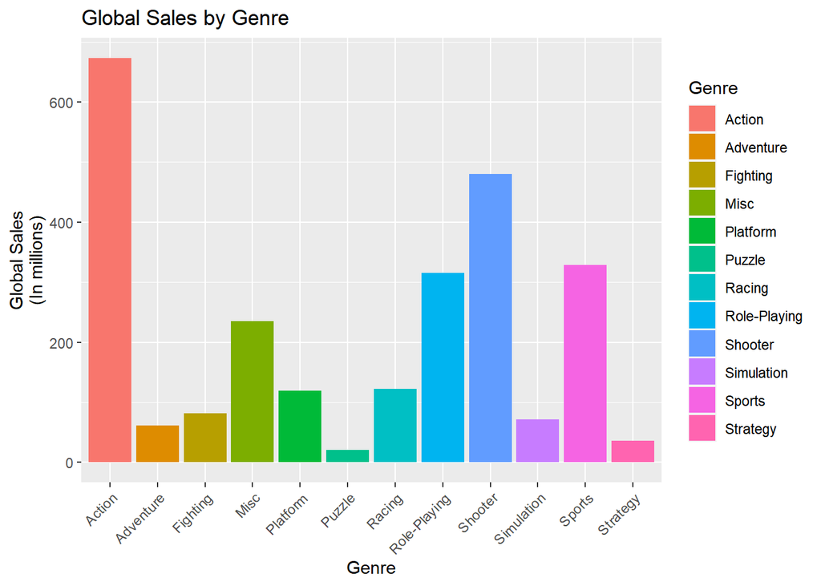

```r
# We use the ggplot2 package to create a Bar graph that easily represents the
                            # highest globally selling video game genre. We use the aes() function to label
                            # the axis’, as well as using fill for discernment between Genres,
                            # geom_bar(stat=”identity”) makes a bar chart and makes the height proportional
                            # to the number of cases in each group. Stat identity displays the sum of
                            # values in the Sales(NA) column, grouped by Genre
                            ggplot(data = genre_glbl_sales, aes(x = Genre, y = genre_glbl_total, fill = Genre)) +
                                geom_bar(stat = "identity") + labs(title = "Global Sales by Genre", x = "Genre",
                                y = "Global Sales\n(In millions)") + theme(axis.text.x = element_text(angle = 45,
                                hjust = 1))
```

```r
# labs() is used to changes the labels in various parts of the chart. Both the
                            # X and Y axis changing their names, as well as the title. theme() helps change
                            # non-data elements of a chart. In this case adding a change to Genre’s axis by
                            # utilizing element_text() to change the look of texts, adding an angle and
                            # using hjust to control horizontal justification
```

This code generates a bar graph that displays the total Global sales of each video game genre between 2010 to 2016.

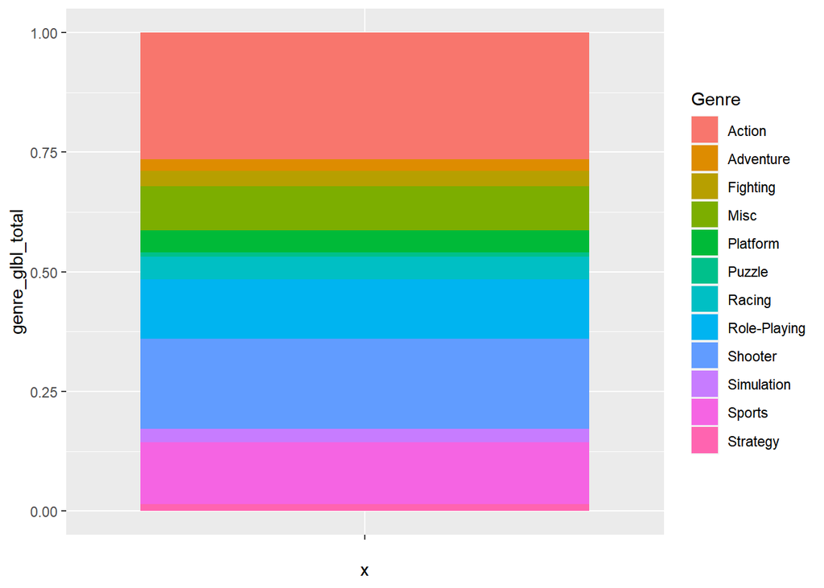

```r
# We convert our numerical values into percentages, then store into pvgsg.
                            PVGSG <- genre_glbl_sales %>%
                                mutate(percentage = paste0(round(genre_glbl_total/sum(genre_glbl_total) * 100,
                                    2), "%"))
                            PVGSG <- PVGSG %>%
                                arrange(desc(genre_glbl_total))

                            # We use ggplot() to create a bar chart, then use aes() to set the parameters
                            # for x and y axis, and use geom_bar() to create a bar chart and then set the
                            # style for to fill.
                            ggplot(PVGSG, aes(fill = Genre, y = genre_glbl_total, x = "")) + geom_bar(position = "fill",
                                stat = "identity")
```

This code displays a stacked bar graph with a couple of functions at play.

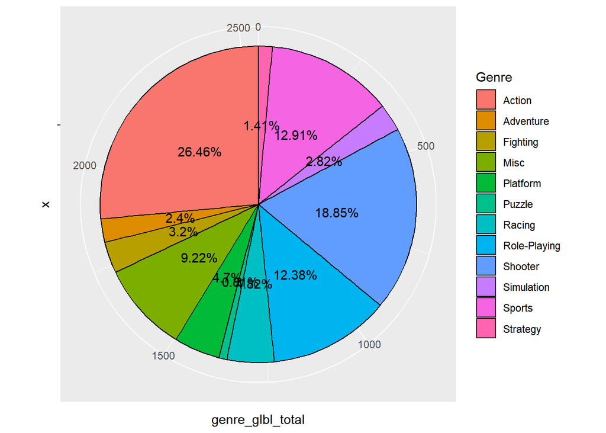

```r
# We convert our numeric values in genre_glbl_sales into a percentage of the
                            # entire sum and store it into pie_labels2.
                            pie_labels2 <- paste0(round(100 * genre_glbl_sales$genre_glbl_total/sum(genre_glbl_sales$genre_glbl_total),
                                2), "%")
                            # We use ggplot() to create the graph, the aes() function set’s the aesthetic.
                            # Used nothing for X, but for Y we used genre_glbl_total so that it would fill
                            # proportionately.We use the reorder() function to reorder the different
                            # Genre's from least to greatest. We then filled it by Genre using a rainbow
                            # palette. the geom_col() function is used to create black lines in between our
                            # “Slices”.
                            ggplot(genre_glbl_sales, aes(x = "", y = genre_glbl_total, fill = Genre)) + geom_col(color = "black") +
                                geom_text(aes(label = pie_labels2), position = position_stack(vjust = 0.5)) +
                                coord_polar(theta = "y")
```

```r
# geom_text is used along with aes() embedded to set labels to pie labels and
                            # position them accordingly. coord_polar is used because a pie chart is
                            # actually just a stacked bar chart in polar coordinates. Then, we use the labs
                            # function to change the name of the y axis and title on the graph.
```

This code creates a pie chart that displays the sum of global sales of video games from 2010 to 2016 in a percentage of the total sales made by Genre.

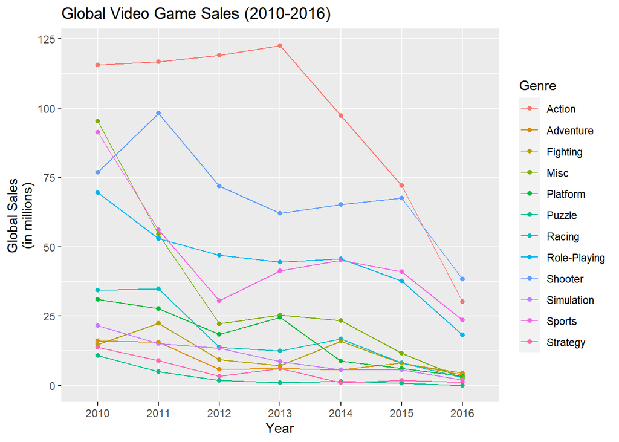

```r
# ggplot() is used to create the graph, and set the aesthetics of the graph.
                            # geom_point() is used to create a scatter plot of each platforms sales from
                            # 2010 to 2016.
                            ggplot(data = genre_SalesbyYear, aes(x = Year_of_Release, y = glbl_total, color = Genre)) +
                                geom_point() + geom_line(aes(group = Genre)) + labs(title = "Global Video Game Sales (2010-2016)",
                                x = "Year", y = "Global Sales\n(in millions)")
```

```r
# Geom_line is used to create a line graph and we set the aesthetic of the
                            # graph to group by Genre. labs() is used to change the names of our x and y
                            # axis as well as the title.
```

This line creates a line chart that shows the decrease/increase in global video game sales each year.

Analysis: Like our previous analysis with question 3, we see that Action is also the most profitable Genre, similar to NA sales. Over six years, the sales of Action games have decreased dramatically, and eventually, Shooter had the most sales in 2016.

5.5 We know the global and NA revenue for each of the top five developers, but now we want to create some visuals to understand their profit from 2010 to 2016 better.

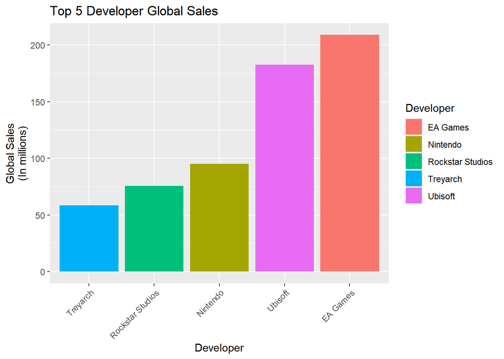

```r
# We use the ggplot2 package to create our graph, the aes() function is used to
                            # set the aesthetics of the plot. we set our x value to Developer and our Y
                            # value to NA sale. we also use the reorder() function to reorder the graph
                            # from smallest to greatest.

                            ggplot(dev_global, aes(x = reorder(Developer, global_total), y = global_total, fill = Developer)) +
                                geom_bar(stat = "identity") + theme(axis.text.x = element_text(angle = 45, hjust = 1)) +
                                labs(title = "Top 5 Developer Global Sales", x = "Developer", y = "Global Sales\n(In millions)")
```

```r
# The geom_bar() function creates a bar plot using the 'identity' statistical
                            # transformation.The theme() function is used to customize the appearance of
                            # the plot. The axis.text.x argument is set to element_text() to change the
                            # angle of the x-axis labels to 45 degrees and set the horizontal justification
                            # to 1 (right align).The labs() function sets the plot title to 'Top 5
                            # Developers by Global Sales', and labels the x-axis 'Developer' and the y-axis
                            # 'Global Game Sales (in millions)'.
```

This code generates a bar chart that ranks the top 5 video game developers by their total global sales across all regions. The sum of sales from all regions for each Developer orders the bars. The x-axis labels are angled and right-aligned for better readability.

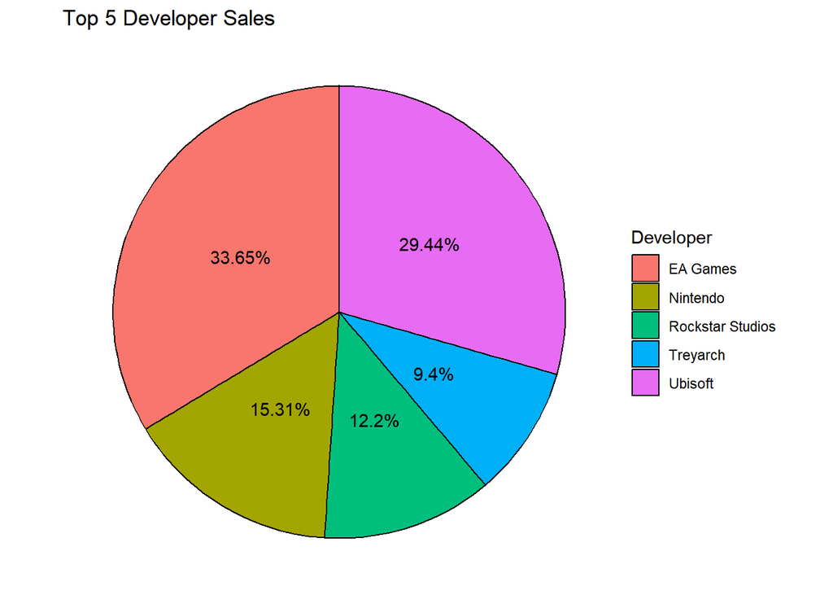

```r
# we convert our numeric values in genre_glbl_sales into a percentage of the
                            # entire sum and store it into pie_labels2.
                            pie_labels3 <- paste0(round(100 * dev_global$global_total/sum(dev_global$global_total),
                                2), "%")
                            # The aes() function is setting the aesthetics of the plot. The x-axis is set
                            # to an empty string, which means there will be no x-axis label. The y-axis is
                            # set to the sum of sales from all regions. The fill aesthetic is set to the
                            # Developer column. The geom_col() function creates a pie chart using the
                            # 'identity' statistical transformation. The width argument is set to 1 to
                            # remove the space between the bars, and the color argument is set to 'black'
                            # to add a white border around each bar. The coord_polar() function is used to
                            # convert the plot to a polar coordinate system. The 'y' argument specifies
                            # that the y-axis values should be used to determine the radial distance of
                            # each bar from the center of the plot. The start argument is set to 0 to align
                            # the first bar with the 12 o'clock position.
                            ggplot(dev_global, aes(x = "", y = global_total, fill = Developer)) + geom_col(stat = "identity",
                                width = 1, color = "black") + coord_polar(theta = "y") + theme_void() + geom_text(aes(label = pie_labels3),
                                position = position_stack(vjust = 0.5)) + labs(title = " Top 5 Developer Sales")
```

```r
# The geom_text() function is used to sum up the percentage each of these five
                            # Developers make globally. The theme_void() function removes all the axis
                            # labels, ticks, and grid lines, leaving only the bars.The labs() function sets
                            # the plot title to 'Top 5 Developer Sales'.
```

5.6 We will now create some visuals for our sixth question to analyze our findings.

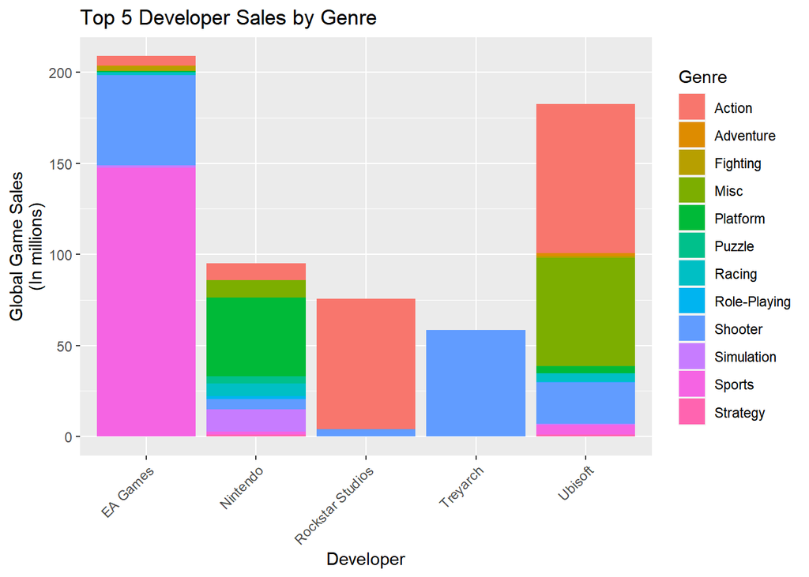

```r
# We use the ggplot2 package in R to show the top 5 video game genres for each
                            # of the top 5 video game developers in terms of global sales. The aes()
                            # function is used to set the aesthetics of the plot. The x-axis is set to the
                            # Developer column, the y-axis is set to the Global_Total column, and the fill
                            # aesthetic is set to the Genre column. The geom_bar() function creates a bar
                            # plot using the 'identity' statistical transformation, which means the bar
                            # heights correspond to the values in the Global_Total column.
                            ggplot(df, aes(x = Developer, y = developer_glbl_total, fill = Genre)) + geom_bar(stat = "identity") +
                                theme(axis.text.x = element_text(angle = 45, hjust = 1)) + labs(title = "Top 5 Developer Sales by Genre",
                                x = "Developer", y = "Global Game Sales\n(In millions)")
```

```r
# The theme() function sets the x-axis text to a 45-degree angle for better
                            # readability, and the labs() function sets the plot title, x-axis label, and
                            # y-axis label.
```

Overall, this code generates a stacked bar chart that shows the contribution of each video game genre to the global sales of the top 5 video game developers. Each bar is divided into segments corresponding to the sales of each Genre, and the height of each bar corresponds to the total global sales of the Developer.

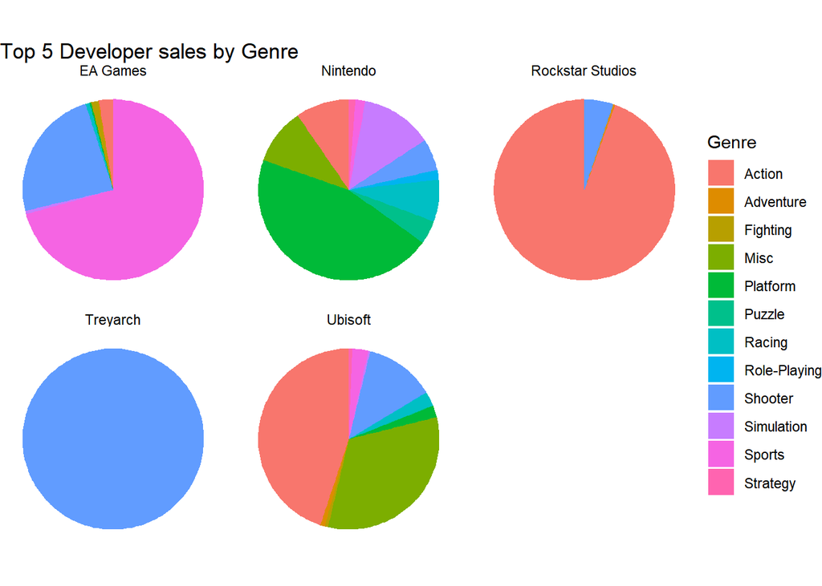

```r
# The aes() function is used to set the aesthetics of the plot. The x-axis is
                            # set to 0, the y-axis is set to the Global_Total column, and the fill
                            # aesthetic is set to the Genre column. The geom_col() function creates a
                            # column plot with position set to 'fill', which stacks the bars so that each
                            # bar fills the available vertical space.
                            ggplot(data = df, aes(x = 0, y = developer_glbl_total, fill = Genre)) + geom_col(position = "fill") +
                                facet_wrap(~Developer) + coord_polar(theta = "y") + theme_void() + labs(title = "Top 5 Developer sales by Genre")
```

```r
# The facet_wrap() function is used to split the plot into multiple panels, one
                            # for each developer. The coord_polar() function converts the plot to polar
                            # coordinates, which makes it easier to compare the relative contributions of
                            # each video game genre across the different developers. The theme_void()
                            # function sets the plot to have no background or axis labels, and the labs()
                            # function sets the plot title.
```

Overall, this code generates a polar bar chart that shows the relative contribution of each video game genre to the global sales of the top 5 video game developers. The chart is split into multiple panels, one for each Developer, making it easy to compare the contribution of each Genre across the different developers.

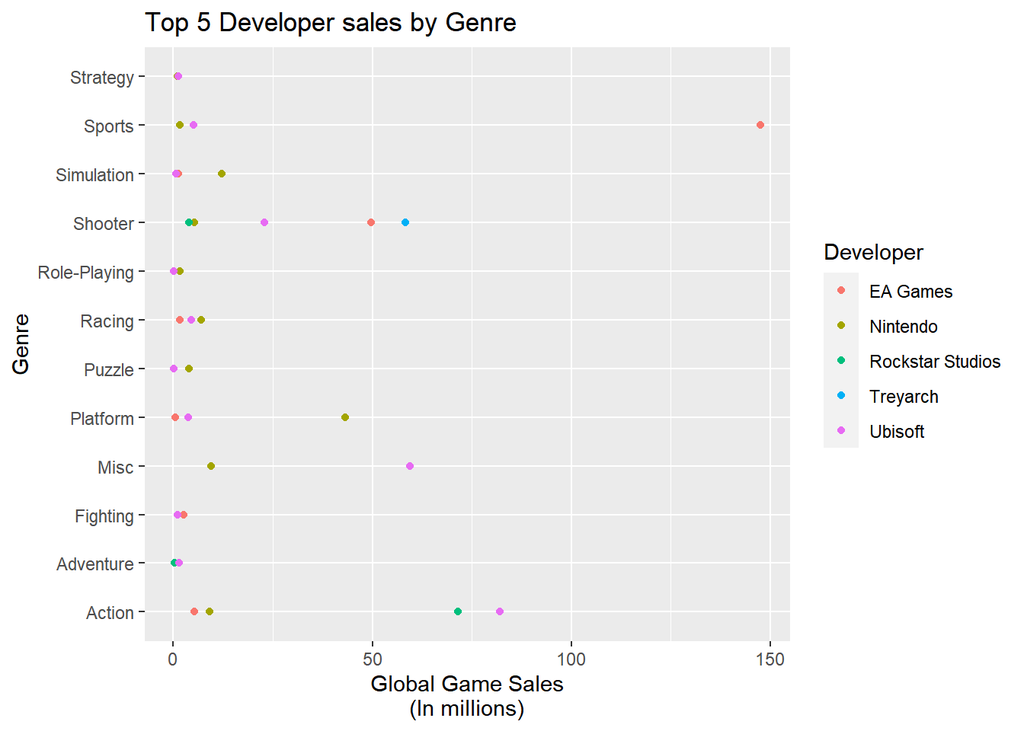

```r
# The aes() function is used to set the aesthetics of the plot. The x-axis is
                            # set to Genre, the y-axis is set to the Global_Total column, and the color
                            # aesthetic is set to the Developer column. The geom_point() function creates a
                            # scatter plot graph.
                            ggplot(data = df, aes(x = Genre, y = developer_glbl_total, colour = Developer)) +
                                geom_point() + labs(title = "Top 5 Developer sales by Genre", x = "Genre", y = "Global Game Sales\n(In millions)") +
                                coord_flip()
```

```r
# We use the labs() function to label our title, x-axis, and y-axis. The
                            # coordflip() flips the x and y axis, so that our x-axis value appear on the
                            # y-axis and our y-axis values appear on the x-axis.
```

Overall this code creates a scatter plot that shows how most categories are similar in sales. However, it also shows that When it comes to Sports games, EA Games make far more profit than any other categories.

# 6. Modelling

After creating our visualizations, we want to create some models to understand the relationship between the datatypes. We will be using five different models in this section: Linear Regression, Multiple Linear Regression, Random Forest, Support Vector Regression (SVR), and Support Vector Machine (SVM).

6.1 Linear Regression

The first model we will be using is linear regression, and we will be using linear regression to establish a relationship between our dependent variable Global_Sales with our independent variable NA_Sales. We want to predict if we can calculate the Global_Sales based on the NA_sales. To start, we first create a model using linear regression.

```r
# Using lm() to create a linear regression model using Global_Sales as
                            # dependent variable and NA_sales as independent variable.
                            global_na_sales_model <- lm(formula = Global_Sales ~ NA_Sales, data = gamesales2010_2016)
                            # Summary() function used to get a summary of the model created.
                            summary(global_na_sales_model)
```

```
##
                            ## Call:
                            ## lm(formula = Global_Sales ~ NA_Sales, data = gamesales2010_2016)
                            ##
                            ## Residuals:
                            ##     Min      1Q  Median      3Q     Max
                            ## -6.3339 -0.0990 -0.0538  0.0146  7.8253
                            ##
                            ## Coefficients:
                            ##             Estimate Std. Error t value Pr(>|t|)
                            ## (Intercept) 0.081547   0.006709   12.15   <2e-16 ***
                            ## NA_Sales    1.870823   0.010331  181.09   <2e-16 ***
                            ## ---
                            ## Signif. codes:  0 '***' 0.001 '**' 0.01 '*' 0.05 '.' 0.1 ' ' 1
                            ##
                            ## Residual standard error: 0.4601 on 5275 degrees of freedom
                            ## Multiple R-squared:  0.8614, Adjusted R-squared:  0.8614
                            ## F-statistic: 3.279e+04 on 1 and 5275 DF,  p-value: < 2.2e-16
```

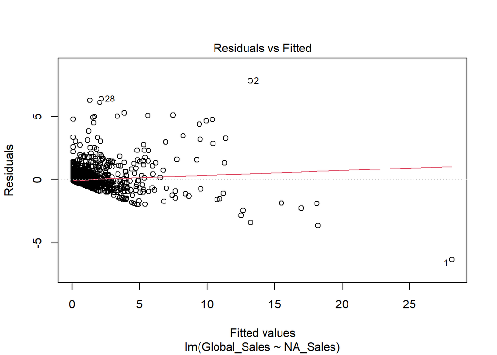

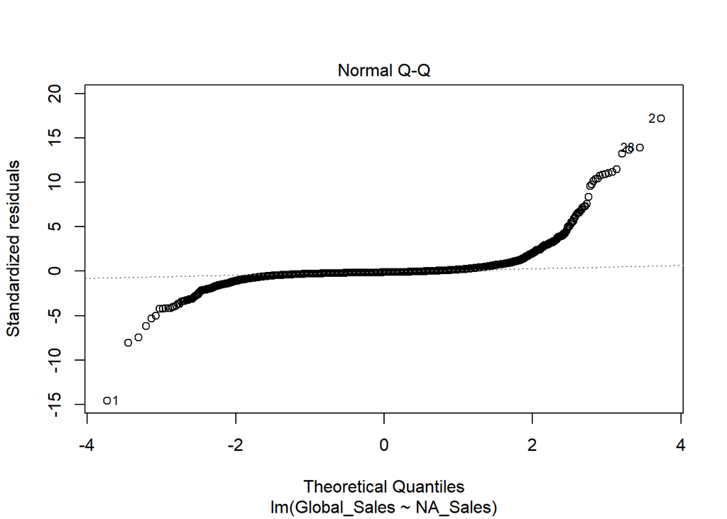

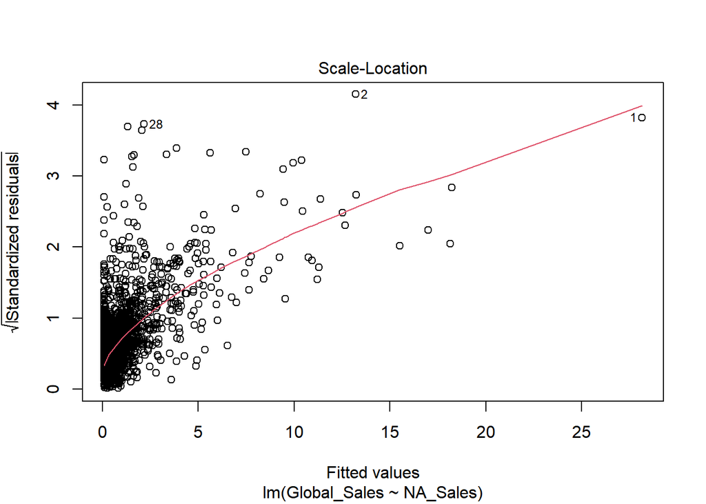

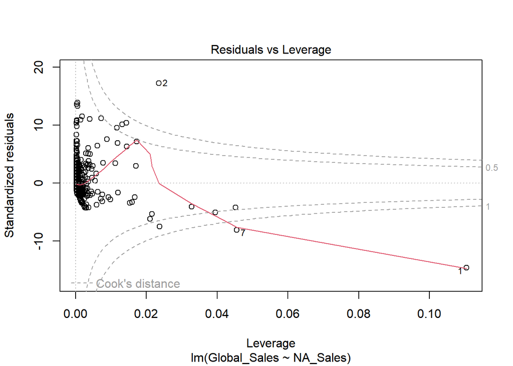

```r
plot(global_na_sales_model)
```

We can see that the p-value is less than our alpha 0.05, meaning that our independent variable is significant in our data set. We also see that our R-Squared is 86%, which means our model fits our dataset.

We will now calculate the percentage error to see the error rate of this model. First, we will find the Residual Standard Error(RSE) of the model and then calculate the mean of Global_Sales. After which, we divide our RSE by the mean and multiply by 100 to find our percentage error, as shown in the code below.

```r
# We calculate the RSE using sigma.
                            rse <- summary(global_na_sales_model)$sigma
                            # We calculate the mean of Global_Sales.
                            y_mean <- mean(gamesales2010_2016$Global_Sales)
                            # We calculate our percentage error.
                            perc_error <- (rse/y_mean) * 100

                            print(perc_error)
```

```
## [1] 95.39015
```

After calculating the percentage error, we see a high percentage error, indicating that our model is not accurate and is not good enough to make predictions with.

```r
# Create a linear Regression model using Global_Sales as dependent variable and
                            # Platform as independent variable.
                            lg_model <- lm(formula = Global_Sales ~ Platform, data = gamesales2010_2016)
                            summary(lg_model)
```

```
##
                            ## Call:
                            ## lm(formula = Global_Sales ~ Platform, data = gamesales2010_2016)
                            ##
                            ## Residuals:
                            ##     Min      1Q  Median      3Q     Max
                            ## -0.7558 -0.4052 -0.3052 -0.0652 21.0442
                            ##
                            ## Coefficients:
                            ##                     Estimate Std. Error t value Pr(>|t|)
                            ## (Intercept)          0.42520    0.03055  13.919  < 2e-16 ***
                            ## PlatformPC          -0.16996    0.06388  -2.660  0.00783 **
                            ## PlatformPlayStation  0.02970    0.04002   0.742  0.45804
                            ## PlatformXbox         0.34065    0.05059   6.733 1.84e-11 ***
                            ## ---
                            ## Signif. codes:  0 '***' 0.001 '**' 0.01 '*' 0.05 '.' 0.1 ' ' 1
                            ##
                            ## Residual standard error: 1.228 on 5273 degrees of freedom
                            ## Multiple R-squared:  0.01318,    Adjusted R-squared:  0.01262
                            ## F-statistic: 23.47 on 3 and 5273 DF,  p-value: 4.355e-15
```

After performing linear regression, we see that the model is significant as it is less than our alpha and that Xbox and PC are also significant as they are less than our alpha 0.05; however, PlayStation is not significant in the model as its p-value is higher than alpha.

Our R-squared is also very low, showing that this model is not a good fit for our dataset, showing that linear regression is not a good model for this data set.

6.2 Multiple Linear Regression

We have tested the linear regression model; however, now we will test the multiple linear regression model on our data set on specific independent variables such as Genre, Year_of_Release, and Platform. Since Developer has too many values, we will restrict it from our model.

```r
mreg <- lm(formula = Global_Sales ~ Genre + Year_of_Release + Platform, data = gamesales2010_2016)
                            summary(mreg)
```

```
##
                            ## Call:
                            ## lm(formula = Global_Sales ~ Genre + Year_of_Release + Platform,
                            ##     data = gamesales2010_2016)
                            ##
                            ## Residuals:
                            ##     Min      1Q  Median      3Q     Max
                            ## -1.4844 -0.4115 -0.2275  0.0016 21.1845
                            ##
                            ## Coefficients:
                            ##                     Estimate Std. Error t value Pr(>|t|)
                            ## (Intercept)          0.42847    0.05074   8.444  < 2e-16 ***
                            ## GenreAdventure      -0.33325    0.06038  -5.520 3.56e-08 ***
                            ## GenreFighting       -0.07760    0.09127  -0.850 0.395244
                            ## GenreMisc           -0.04880    0.06084  -0.802 0.422496
                            ## GenrePlatform        0.33299    0.10307   3.231 0.001242 **
                            ## GenrePuzzle         -0.20953    0.11943  -1.754 0.079415 .
                            ## GenreRacing          0.05764    0.08483   0.680 0.496837
                            ## GenreRole-Playing    0.11824    0.05966   1.982 0.047537 *
                            ## GenreShooter         0.69947    0.06844  10.221  < 2e-16 ***
                            ## GenreSimulation     -0.05293    0.08919  -0.593 0.552885
                            ## GenreSports          0.09503    0.05980   1.589 0.112116
                            ## GenreStrategy       -0.14346    0.09954  -1.441 0.149587
                            ## Year_of_Release2011 -0.04196    0.04961  -0.846 0.397687
                            ## Year_of_Release2012  0.04443    0.05940   0.748 0.454492
                            ## Year_of_Release2013  0.12057    0.06273   1.922 0.054674 .
                            ## Year_of_Release2014  0.05487    0.06176   0.888 0.374344
                            ## Year_of_Release2015 -0.06118    0.06126  -0.999 0.317995
                            ## Year_of_Release2016 -0.26361    0.06533  -4.035 5.54e-05 ***
                            ## PlatformPC          -0.22466    0.06544  -3.433 0.000601 ***
                            ## PlatformPlayStation  0.03198    0.04210   0.760 0.447477
                            ## PlatformXbox         0.24587    0.05211   4.718 2.44e-06 ***
                            ## ---
                            ## Signif. codes:  0 '***' 0.001 '**' 0.01 '*' 0.05 '.' 0.1 ' ' 1
                            ##
                            ## Residual standard error: 1.203 on 5256 degrees of freedom
                            ## Multiple R-squared:  0.05561,    Adjusted R-squared:  0.05202
                            ## F-statistic: 15.48 on 20 and 5256 DF,  p-value: < 2.2e-16
```

In this model, we are using multiple attributes, so we look at our adjusted R-squared; from the adjusted R-squared, we see that our R-squared is only 5%. This means the model is not a good fit for our data set, and we do not have to proceed any further, as multiple linear regression is not a good fit for our data set.

6.3 Random Forest Model

Now, We will attempt the Random forest model to see if we can use our dataset to make predictions. First, we will need to load two different packages.

```r
# Load randomForest package and caret packages
                            library(randomForest)
library(caret)
```

Afterward, we must omit all N/A values and split the dataset into our train and test data. Then we train our model. After training our model, we will test it to evaluate its performance and identify problems such as overfitting.

```r
g <- gamesales2010_2016
                            # Remove N/A values
                            g <- na.omit(g)
                            # Make the Genre Column a factor
                            g$Genre <- as.factor(g$Genre)


                            set.seed(123)
                            # Split the data into train and test
                            trainIndex <- createDataPartition(g$Global_Sales, p = 0.8, list = FALSE)
                            train <- g[trainIndex, ]
                            test <- g[-trainIndex, ]
                            # Run the RandomForest model
                            model <- randomForest(Genre ~ ., data = train, importance = TRUE, ntree = 30)
                            # Create a prediction
                            predictions <- predict(model, test)
                            # use Confusion Matrix
                            confusionMatrix(predictions, test$Genre)
```

```
## Confusion Matrix and Statistics
                            ##
                            ##               Reference
                            ## Prediction     Action Adventure Fighting Misc Platform Puzzle Racing
                            ##   Action           86         7       15   15        8      1     10
                            ##   Adventure         0         0        1    0        0      0      0
                            ##   Fighting          2         1        2    1        0      0      0
                            ##   Misc              2         0        0    4        1      0      0
                            ##   Platform          1         0        0    2        1      0      0
                            ##   Puzzle            1         0        0    1        0      0      0
                            ##   Racing            6         1        0    0        3      0      8
                            ##   Role-Playing      7         2        1    1        1      0      1
                            ##   Shooter          24         4        4    2        2      0      4
                            ##   Simulation        0         0        0    1        1      0      0
                            ##   Sports            1         2        0    5        1      1      3
                            ##   Strategy          0         0        0    0        0      0      0
                            ##               Reference
                            ## Prediction     Role-Playing Shooter Simulation Sports Strategy
                            ##   Action                 27      26          8     11        5
                            ##   Adventure               1       0          0      0        0
                            ##   Fighting                2       0          0      0        0
                            ##   Misc                    0       0          0      1        0
                            ##   Platform                1       0          1      0        0
                            ##   Puzzle                  0       0          0      0        0
                            ##   Racing                  0       0          1     17        2
                            ##   Role-Playing           13       1          0      0        0
                            ##   Shooter                10      31          1      3        2
                            ##   Simulation              0       0          0      2        0
                            ##   Sports                  0       0          1      9        1
                            ##   Strategy                0       0          0      0        1
                            ##
                            ## Overall Statistics
                            ##
                            ##                Accuracy : 0.3638
                            ##                  95% CI : (0.3181, 0.4115)
                            ##     No Information Rate : 0.3052
                            ##     P-Value [Acc > NIR] : 0.005486
                            ##
                            ##                   Kappa : 0.1974
                            ##
```

[output cut: 25 more lines]

```
                            ## Pos Pred Value                   0.48148        0.35632           0.00000
                            ## Neg Pred Value                   0.89724        0.92035           0.97156
                            ## Prevalence                       0.12676        0.13615           0.02817
                            ## Detection Rate                   0.03052        0.07277           0.00000
                            ## Detection Prevalence             0.06338        0.20423           0.00939
                            ## Balanced Accuracy                0.60155        0.69115           0.49517
                            ##                      Class: Sports Class: Strategy
                            ## Sensitivity                0.20930        0.090909
                            ## Specificity                0.96084        1.000000
                            ## Pos Pred Value             0.37500        1.000000
                            ## Neg Pred Value             0.91542        0.976471
                            ## Prevalence                 0.10094        0.025822
                            ## Detection Rate             0.02113        0.002347
                            ## Detection Prevalence       0.05634        0.002347
                            ## Balanced Accuracy          0.58507        0.545455
```

```r
mean(predictions == test$Genre)
```

```
## [1] 0.3638498
```

```r
summary(model)
```

```
##                 Length Class  Mode
                            ## call                5  -none- call
                            ## type                1  -none- character
                            ## predicted        1712  factor numeric
                            ## err.rate          390  -none- numeric
                            ## confusion         156  -none- numeric
                            ## votes           20544  matrix numeric
                            ## oob.times        1712  -none- numeric
                            ## classes            12  -none- character
                            ## importance        210  -none- numeric
                            ## importanceSD      195  -none- numeric
                            ## localImportance     0  -none- NULL
                            ## proximity           0  -none- NULL
                            ## ntree               1  -none- numeric
                            ## mtry                1  -none- numeric
                            ## forest             14  -none- list
                            ## y                1712  factor numeric
                            ## test                0  -none- NULL
                            ## inbag               0  -none- NULL
                            ## terms               3  terms  call
```

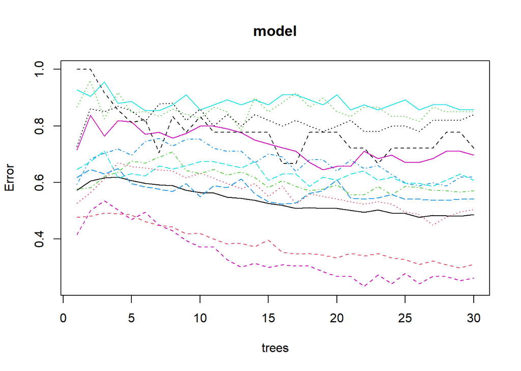

```r
plot(model)
```

From the results above, Random Forest modeling is not a good model for our dataset. So we cannot use this model to help us make predictions or classifications on the data set.

6.4 Support Vector Regression (SVR)

We will now use SVR to make predictions on our model. We add a new library and split our dataset into test and train data. Then we will make all attributes numeric, attempt to do a linear kernel model, then analyze the model.

```r
library(e1071)
# Creating a separate data set with Year_of_release and Global_Sales values
                            gamesales2010_2016_model <- gamesales2010_2016[, c("Year_of_Release", "Global_Sales")]

                            # Partition data into test and training by 80:20
                            set.seed(123)
                            train_index <- sample(nrow(gamesales2010_2016_model), nrow(gamesales2010_2016_model) *
                                0.8)
                            train_data <- gamesales2010_2016_model[train_index, ]
                            test_data <- gamesales2010_2016_model[-train_index, ]

                            # Making sure all the values in the Year_of_Release column are numberic
                            gamesales2010_2016_model$Year_of_Release <- as.numeric(gamesales2010_2016_model$Year_of_Release)

                            # Calling a tune function to find optimal parameters for the model
                            tuned <- tune(svm, Global_Sales ~ Year_of_Release, data = train_data, kernel = "radial",
                                ranges = list(cost = c(0.1, 1, 10), gamma = c(0.01, 0.1, 1)))
                            # Building a model with radial kernel and tuned cost and gamma parameters
                            model <- svm(Global_Sales ~ Year_of_Release, data = train_data, kernel = "radial",
                                cost = tuned$best.parameters$cost, gamma = tuned$best.parameters$gamma, type = "eps-regression")
                            summary(model)
```

```
##
                            ## Call:
                            ## svm(formula = Global_Sales ~ Year_of_Release, data = train_data,
                            ##     kernel = "radial", cost = tuned$best.parameters$cost, gamma = tuned$best.parameters$gamma,
                            ##     type = "eps-regression")
                            ##
                            ##
                            ## Parameters:
                            ##    SVM-Type:  eps-regression
                            ##  SVM-Kernel:  radial
                            ##        cost:  1
                            ##       gamma:  1
                            ##     epsilon:  0.1
                            ##
                            ##
                            ## Number of Support Vectors:  2709
```

```r
# Attempting a linear kernel model
                            model2 <- svm(Global_Sales ~ Year_of_Release, data = train_data, kernel = "linear")
                            summary(model2)
```

```
##
                            ## Call:
                            ## svm(formula = Global_Sales ~ Year_of_Release, data = train_data,
                            ##     kernel = "linear")
                            ##
                            ##
                            ## Parameters:
                            ##    SVM-Type:  eps-regression
                            ##  SVM-Kernel:  linear
                            ##        cost:  1
                            ##       gamma:  0.1428571
                            ##     epsilon:  0.1
                            ##
                            ##
                            ## Number of Support Vectors:  2709
```

```r
# Attempting a polynomial kernel with degree of 2
                            model3 <- svm(Global_Sales ~ Year_of_Release, data = train_data, kernel = "polynomial",
                                degree = 2)
                            summary(model3)
```

```
##
                            ## Call:
                            ## svm(formula = Global_Sales ~ Year_of_Release, data = train_data,
                            ##     kernel = "polynomial", degree = 2)
                            ##
                            ##
                            ## Parameters:
                            ##    SVM-Type:  eps-regression
                            ##  SVM-Kernel:  polynomial
                            ##        cost:  1
                            ##      degree:  2
                            ##       gamma:  0.1428571
                            ##      coef.0:  0
                            ##     epsilon:  0.1
                            ##
                            ##
                            ## Number of Support Vectors:  2713
```

```r
pred <- predict(model3, newdata = test_data)


                            # Analyzing Metrics
                            mse <- mean((pred - test_data$Global_Sales)^2)
                            rsq <- 1 - sum((test_data$Global_Sales - pred)^2)/sum((test_data$Global_Sales - mean(test_data$Global_Sales))^2)
                            mae <- mean(abs(test_data$Global_Sales - pred))
                            print(paste0("Mean Squared Error: ", mse))
```

```
## [1] "Mean Squared Error: 1.67536601872764"
```

```r
cat("R-squared:", rsq, "\n")
```

```
## R-squared: -0.06044289
```

```r
cat("Mean Absolute Error:", mae, "\n")
```

```
## Mean Absolute Error: 0.4385891
```

6.5 SVM

We are creating an SVM to help us predict our Genre based on sales; the code below shows the steps taken.

```r
VGSales <- gamesales2010_2016
                            VGSales1 <- VGSales %>%
                                filter(Genre != "")

                            # Aggregate Sum of NA and EU Sales
                            VGSASum <- aggregate(cbind(NA_Sales, EU_Sales) ~ Genre, VGSales1, FUN = sum)

                            # Create New Class Definition of 'Action Type' and 'Strategy Type'
                            VGSASum %>%
                                mutate(Class = c(1, 1, 1, -1, -1, -1, 1, -1, 1, -1, 1, -1))
```

```
##           Genre NA_Sales EU_Sales Class
                            ## 1        Action   290.64   233.63     1
                            ## 2     Adventure    20.84    18.88     1
                            ## 3      Fighting    39.05    20.33     1
                            ## 4          Misc   123.80    66.09    -1
                            ## 5      Platform    54.90    38.30    -1
                            ## 6        Puzzle     9.10     6.58    -1
                            ## 7        Racing    46.11    54.75     1
                            ## 8  Role-Playing   112.05    75.48    -1
                            ## 9       Shooter   237.47   171.45     1
                            ## 10   Simulation    26.39    26.39    -1
                            ## 11       Sports   156.81   116.84     1
                            ## 12     Strategy    13.25    12.49    -1
```

```r
View(VGSASum)


                            VGSASum <- VGSASum %>%
                                mutate(Class = c(1, 1, 1, -1, -1, -1, 1, -1, 1, -1, 1, -1))

                            # Create Action Definition Variable
                            isAction <- c(rep(-1, 6), rep(+1, 6))

                            # Create Data Frame For Model
                            my.data <- data.frame(NA_Sales = VGSASum["NA_Sales"], EU_Sales = VGSASum["EU_Sales"],
                                Class = as.factor(isAction))
                            View(my.data)


                            # Plot Data
                            plot(my.data[, -3], col = (3)/2, pch = 19)
                            abline(h = 0, v = 0, lty = 3)

                            # Create SVM Model
                            svm.model <- svm(Class ~ ., data = my.data, type = "C-classification", kernel = "linear",
                                scale = FALSE)
                            summary(svm.model)
```

```
##
                            ## Call:
                            ## svm(formula = Class ~ ., data = my.data, type = "C-classification",
                            ##     kernel = "linear", scale = FALSE)
                            ##
                            ##
                            ## Parameters:
                            ##    SVM-Type:  C-classification
                            ##  SVM-Kernel:  linear
                            ##        cost:  1
                            ##
                            ## Number of Support Vectors:  11
                            ##
                            ##  ( 5 6 )
                            ##
                            ##
                            ## Number of Classes:  2
                            ##
                            ## Levels:
                            ##  -1 1
```

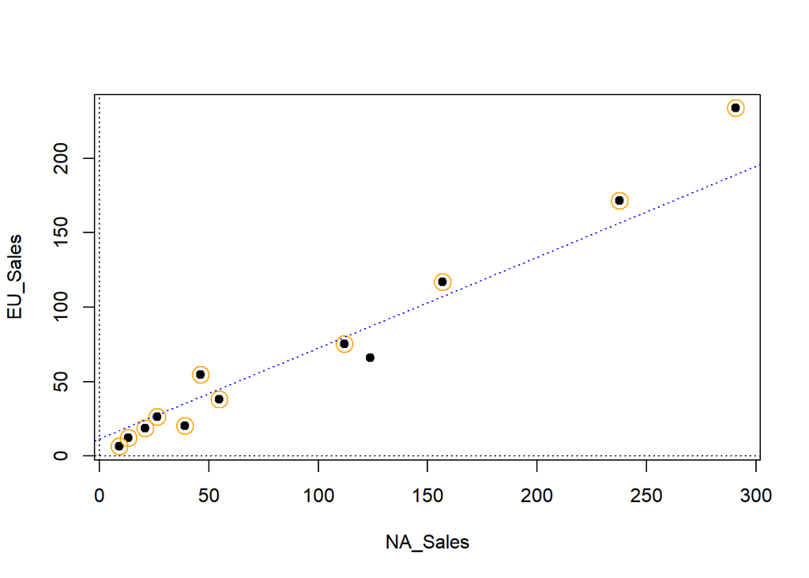

```r
# Plot Points for Decision Paramters
                            points(my.data[svm.model$index, c(1, 2)], col = "orange", cex = 2)

                            w <- t(svm.model$coefs) %*% svm.model$SV
                            b <- -svm.model$rho
                            abline(a = -b/w[1, 2], b = -w[1, 1]/w[1, 2], col = "blue", lty = 3)
```

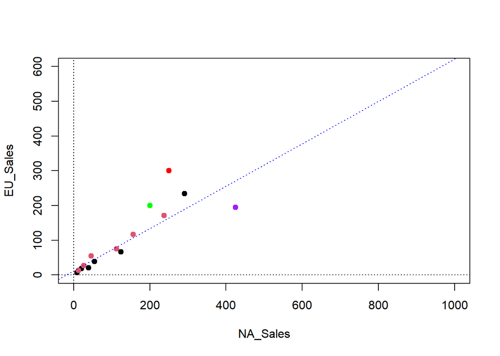

```r
# Set Test Data
                            observations <- data.frame(NA_Sales = c(200, 250, 425), EU_Sales = c(200, 300, 195))

                            # Plot Test Data
                            plot(my.data[, -3], col = (isAction + 3)/2, pch = 19, xlim = c(0, 1000), ylim = c(0,
                                600))
                            abline(h = 0, v = 0, lty = 3)
                            points(observations[1, ], col = "green", pch = 19)
                            points(observations[2, ], col = "red", pch = 19)
                            points(observations[3, ], col = "purple", pch = 19)

                            # Predict Data (Data is correct here, small mistake led to inversion of 1 and
                            # -1 as assingments. Prediciton is correct
                            abline(a = -b/w[1, 2], b = -w[1, 1]/w[1, 2], col = "blue", lty = 3)
```

```r
predict(svm.model, observations)
```

```
##  1  2  3
                            ##  1  1 -1
                            ## Levels: -1 1
```

```r
View(my.data)
                            View(VGSASum)
                            View(my.data)
```

Like the other models, this model is terrible for this dataset. To use SVM in this dataset, the data had to be aggregated and controlled to the point that would allow the model to make correct predictions. Though we had made the model make some predictions, this model is not efficient for this data set.

# 7. Conclusion

Although modeling does not work on this dataset, one thing that can be seen is that this data set works well with visualizations. Though we cannot use modeling to predict this dataset, we can use visualizations to show the trends between different attributes in our data set. We are also able to determine different things from our data set as well.

To solve our client’s problem, we attempted to use modeling to make predictions but failed as modeling did not fit this dataset. However, we were able to use visualizations; in these visualizations, we were able to get some insight from the data and were able to determine that though Action games were the most profitable games between 2010 to 2016 in NA Sales and Global Sales, we see a massive trend of the sales of Action Games declining, and if the client is interested in investing based on a genre the best Genre to invest in would be Shooter since compared to other genres its sales globally and in North America has not decreased and was the most profitable Genre in 2016.

We can also conclude that if the Developer is interested in which Platform is the most profitable to invest in, we would suggest that PlayStation would be the best. The reason is that Though Xbox had the highest sales as a whole between 2010 and 2016, compared to PlayStation, the video game sales that are based on the Platform Xbox have decreased dramatically, while PlayStation has not decreased as much and by 2016 had been having more video game sales compared to other Platforms.

Also, from what we have gathered about the game developers, though we found that EA Games had made the most global sales, it would be better to invest in Ubisoft, which had the second-highest sales. This conclusion was based on the fact that Though EA Games made the most money between 2010 and 2016, EA Games’ profit is mainly from Sports games rather than other genres. So if a year were to happen where sports games were unpopular, EA Games video game sales would decrease dramatically. Compared to EA Games, Ubisoft has a diversified portfolio where if one video game genre sales are not doing well, it will not significantly affect its game sales.